# Assignment3_final

### Import necessary libraries

```r
library(tidyverse)
library(dplyr)
library(modelr)
library(reshape2)
library(caret)
library(plotROC)
library(psych)
#library(MASS)

# temporarily suppress display warnings
options(warn=-1)
set.seed(23029)
```

```r
# set plot options
options(repr.plot.height=4.5, repr.matrix.max.rows=15)
```

### Read and Load Data

```r
column_names = c("CAccountStatus","month","credHistory","purpose","credAmount","savingAcct","employedSince","installmentRate","personalStatusAndSex","debators","residenceSince","property","age","installmentPlans","housing","numOfExistingCredits","job","peopleLiableToMaintenance","telephone","foreignWorkers","outcome")
credit_raw = read_delim("german.data.txt", delim=" ",col_names=column_names)
```

```r
#converting boolean valued column into logical column
credit_raw =credit_raw %>% mutate(GoodRisk = outcome == 1 )
head(credit_raw)
```

| CAccountStatus | month | credHistory | purpose | credAmount | savingAcct | employedSince | installmentRate | personalStatusAndSex | debators | ⋯ | age | installmentPlans | housing | numOfExistingCredits | job | peopleLiableToMaintenance | telephone | foreignWorkers | outcome | GoodRisk |
| --- | --- | --- | --- | --- | --- | --- | --- | --- | --- | --- | --- | --- | --- | --- | --- | --- | --- | --- | --- | --- |
| A11 | 6 | A34 | A43 | 1169 | A65 | A75 | 4 | A93 | A101 | ⋯ | 67 | A143 | A152 | 2 | A173 | 1 | A192 | A201 | 1 | TRUE |
| A12 | 48 | A32 | A43 | 5951 | A61 | A73 | 2 | A92 | A101 | ⋯ | 22 | A143 | A152 | 1 | A173 | 1 | A191 | A201 | 2 | FALSE |
| A14 | 12 | A34 | A46 | 2096 | A61 | A74 | 2 | A93 | A101 | ⋯ | 49 | A143 | A152 | 1 | A172 | 2 | A191 | A201 | 1 | TRUE |
| A11 | 42 | A32 | A42 | 7882 | A61 | A74 | 2 | A93 | A103 | ⋯ | 45 | A143 | A153 | 1 | A173 | 2 | A191 | A201 | 1 | TRUE |
| A11 | 24 | A33 | A40 | 4870 | A61 | A73 | 3 | A93 | A101 | ⋯ | 53 | A143 | A153 | 2 | A173 | 2 | A191 | A201 | 2 | FALSE |
| A14 | 36 | A32 | A46 | 9055 | A65 | A73 | 2 | A93 | A101 | ⋯ | 35 | A143 | A153 | 1 | A172 | 2 | A192 | A201 | 1 | TRUE |

```r
## converting categorical data into factor and ordered factor

convert_to_factor = function(credit_raw) {
    credit_raw$CAccountStatus = factor(credit_raw$CAccountStatus,ordered=TRUE)

    credit_raw$credHistory = factor(credit_raw$credHistory)

    credit_raw$purpose = factor(credit_raw$purpose)

    credit_raw$savingAcct = factor(credit_raw$savingAcct,ordered=TRUE)

    credit_raw$employedSince = factor(credit_raw$employedSince,ordered=TRUE)

    credit_raw$personalStatusAndSex = factor(credit_raw$personalStatusAndSex)

    credit_raw$debators = factor(credit_raw$debators)

    credit_raw$property = factor(credit_raw$property)

    credit_raw$installmentPlans = factor(credit_raw$installmentPlans)

    credit_raw$housing = factor(credit_raw$housing)


    credit_raw$job = factor(credit_raw$job)


    credit_raw$telephone = factor(credit_raw$telephone)


    credit_raw$foreignWorkers = factor(credit_raw$foreignWorkers)



    credit_raw$employedSince = factor(credit_raw$employedSince)


    return (credit_raw)
}
```

```r
credit_raw = convert_to_factor(credit_raw)
```

```r
sapply(credit_raw, class)
```

**$CAccountStatus**

1. 'ordered'

2. 'factor'

**$month**

'integer'

**$credHistory**

'factor'

**$purpose**

'factor'

**$credAmount**

'integer'

**$savingAcct**

1. 'ordered'

2. 'factor'

**$employedSince**

1. 'ordered'

2. 'factor'

**$installmentRate**

'integer'

**$personalStatusAndSex**

'factor'

**$debators**

'factor'

**$residenceSince**

'integer'

**$property**

'factor'

**$age**

'integer'

**$installmentPlans**

'factor'

**$housing**

'factor'

**$numOfExistingCredits**

'integer'

**$job**

'factor'

**$peopleLiableToMaintenance**

'integer'

**$telephone**

'factor'

**$foreignWorkers**

'factor'

**$outcome**

'integer'

**$GoodRisk**

'logical'

## Split dataset into training , tune & test set

Train set is used only to train the models. Test set is used to evalaute if the best trained model also performs better in the unseen data (test).

Steps:

1. Add a `id` column
2. Sample rows
3. anti-join to make train data

```r
credit_raw_with_id = credit_raw %>%
mutate(id=1:n())
head(credit_raw_with_id,5)
```

| CAccountStatus | month | credHistory | purpose | credAmount | savingAcct | employedSince | installmentRate | personalStatusAndSex | debators | ⋯ | installmentPlans | housing | numOfExistingCredits | job | peopleLiableToMaintenance | telephone | foreignWorkers | outcome | GoodRisk | id |
| --- | --- | --- | --- | --- | --- | --- | --- | --- | --- | --- | --- | --- | --- | --- | --- | --- | --- | --- | --- | --- |
| A11 | 6 | A34 | A43 | 1169 | A65 | A75 | 4 | A93 | A101 | ⋯ | A143 | A152 | 2 | A173 | 1 | A192 | A201 | 1 | TRUE | 1 |
| A12 | 48 | A32 | A43 | 5951 | A61 | A73 | 2 | A92 | A101 | ⋯ | A143 | A152 | 1 | A173 | 1 | A191 | A201 | 2 | FALSE | 2 |
| A14 | 12 | A34 | A46 | 2096 | A61 | A74 | 2 | A93 | A101 | ⋯ | A143 | A152 | 1 | A172 | 2 | A191 | A201 | 1 | TRUE | 3 |
| A11 | 42 | A32 | A42 | 7882 | A61 | A74 | 2 | A93 | A103 | ⋯ | A143 | A153 | 1 | A173 | 2 | A191 | A201 | 1 | TRUE | 4 |
| A11 | 24 | A33 | A40 | 4870 | A61 | A73 | 3 | A93 | A101 | ⋯ | A143 | A153 | 2 | A173 | 2 | A191 | A201 | 2 | FALSE | 5 |

spilt 10% of dataset as test set

```r
test_credit_raw = credit_raw_with_id %>%
                sample_frac(0.1)
nrow(test_credit_raw)
head(test_credit_raw,5)
```

100

| CAccountStatus | month | credHistory | purpose | credAmount | savingAcct | employedSince | installmentRate | personalStatusAndSex | debators | ⋯ | installmentPlans | housing | numOfExistingCredits | job | peopleLiableToMaintenance | telephone | foreignWorkers | outcome | GoodRisk | id |
| --- | --- | --- | --- | --- | --- | --- | --- | --- | --- | --- | --- | --- | --- | --- | --- | --- | --- | --- | --- | --- |
| A13 | 6 | A32 | A40 | 709 | A64 | A72 | 2 | A94 | A101 | ⋯ | A143 | A152 | 1 | A171 | 1 | A191 | A202 | 1 | TRUE | 141 |
| A11 | 12 | A32 | A42 | 1620 | A61 | A73 | 2 | A92 | A102 | ⋯ | A143 | A152 | 1 | A173 | 1 | A191 | A201 | 1 | TRUE | 442 |
| A14 | 10 | A32 | A40 | 1597 | A63 | A73 | 3 | A93 | A101 | ⋯ | A143 | A151 | 1 | A172 | 2 | A191 | A202 | 1 | TRUE | 414 |
| A11 | 15 | A32 | A43 | 1053 | A61 | A72 | 4 | A94 | A101 | ⋯ | A143 | A152 | 1 | A173 | 1 | A191 | A202 | 1 | TRUE | 408 |
| A12 | 6 | A32 | A43 | 484 | A61 | A74 | 3 | A94 | A103 | ⋯ | A141 | A152 | 1 | A172 | 1 | A191 | A201 | 1 | TRUE | 812 |

Remaining 90% of dataset is defined as train set that are not test data

```r
train_credit_raw = credit_raw_with_id %>% anti_join(select(test_credit_raw, id))
head(train_credit_raw,5)
nrow(train_credit_raw)
```

| CAccountStatus | month | credHistory | purpose | credAmount | savingAcct | employedSince | installmentRate | personalStatusAndSex | debators | ⋯ | installmentPlans | housing | numOfExistingCredits | job | peopleLiableToMaintenance | telephone | foreignWorkers | outcome | GoodRisk | id |
| --- | --- | --- | --- | --- | --- | --- | --- | --- | --- | --- | --- | --- | --- | --- | --- | --- | --- | --- | --- | --- |
| A12 | 45 | A34 | A41 | 4576 | A62 | A71 | 3 | A93 | A101 | ⋯ | A143 | A152 | 1 | A173 | 1 | A191 | A201 | 1 | TRUE | 1000 |
| A11 | 45 | A32 | A43 | 1845 | A61 | A73 | 4 | A93 | A101 | ⋯ | A143 | A153 | 1 | A173 | 1 | A192 | A201 | 2 | FALSE | 999 |
| A14 | 12 | A32 | A43 | 804 | A61 | A75 | 4 | A93 | A101 | ⋯ | A143 | A152 | 1 | A173 | 1 | A191 | A201 | 1 | TRUE | 998 |
| A11 | 30 | A32 | A41 | 3857 | A61 | A73 | 4 | A91 | A101 | ⋯ | A143 | A152 | 1 | A174 | 1 | A192 | A201 | 1 | TRUE | 997 |
| A14 | 12 | A32 | A42 | 1736 | A61 | A74 | 3 | A92 | A101 | ⋯ | A143 | A152 | 1 | A172 | 1 | A191 | A201 | 1 | TRUE | 996 |

900

### Plots

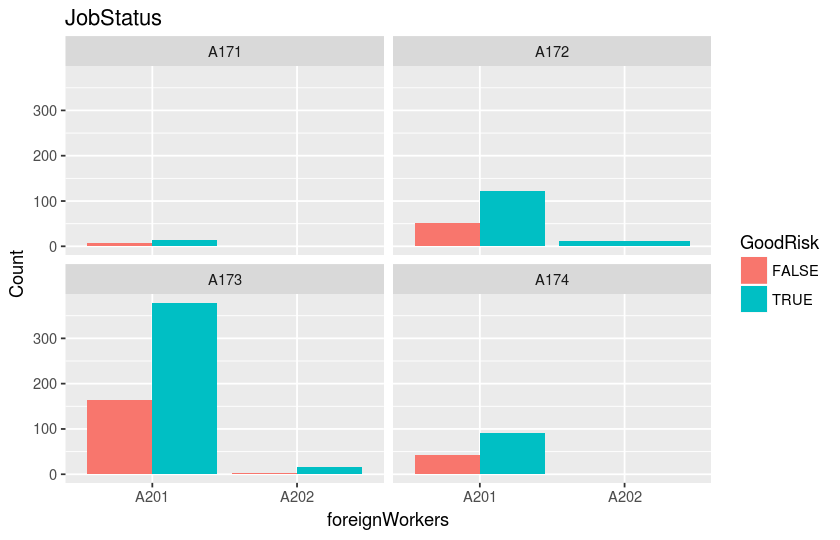

```r
ggplot(train_credit_raw) +
    aes(x=foreignWorkers, fill = GoodRisk)+
    geom_bar(position=position_dodge()) +
    facet_wrap(~job)+
    ggtitle("JobStatus")+
    xlab("foreignWorkers")+
    ylab("Count")+
    labs(fill = "GoodRisk")
```

### Observation

Foreign workers who are skilled employee or official are the ones that should be given credit.

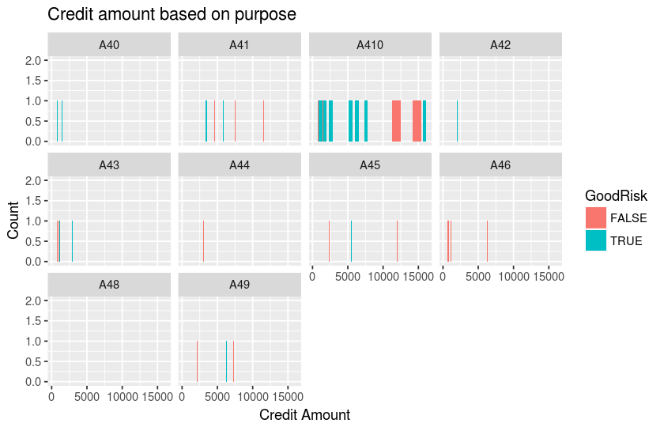

```r
ggplot(train_credit_raw) +
    aes(x=credAmount, fill = GoodRisk)+
    geom_bar(position=position_dodge()) +
    facet_wrap(~purpose)+
    ggtitle("Credit amount based on purpose")+
    xlab("Credit Amount")+
    ylab("Count")+
    labs(fill = "GoodRisk")
```

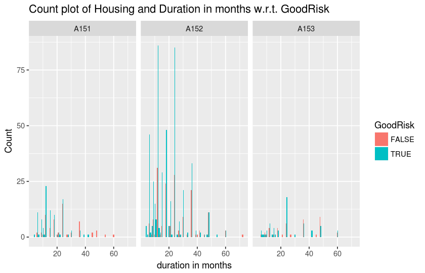

```r
ggplot(train_credit_raw) +
    aes(x=month, fill = GoodRisk)+
    geom_bar(position=position_dodge()) +
    facet_wrap(~housing)+
    ggtitle("Count plot of Housing and Duration in months w.r.t. GoodRisk")+
    xlab("duration in months")+
    ylab("Count")+
    labs(fill = "GoodRisk")
```

It seems that people who either own their own house or live in rent are good candidates for credit.

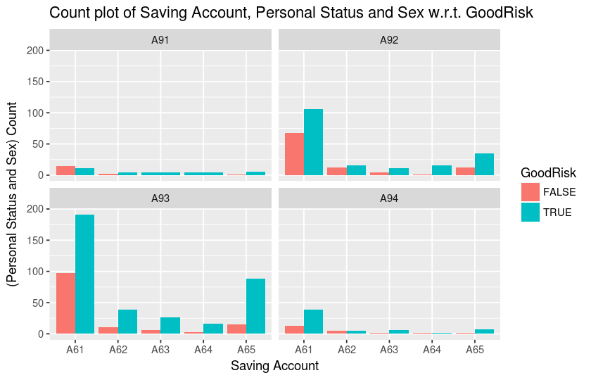

```r
ggplot(train_credit_raw) +
    ggtitle("Count plot of Saving Account, Personal Status and Sex w.r.t. GoodRisk")+
    aes(x=savingAcct, fill = GoodRisk)+
    geom_bar(position=position_dodge()) +
    facet_wrap(~personalStatusAndSex)+
    xlab("Saving Account")+
    ylab("(Personal Status and Sex) Count")+
    labs(fill = "GoodRisk")
```

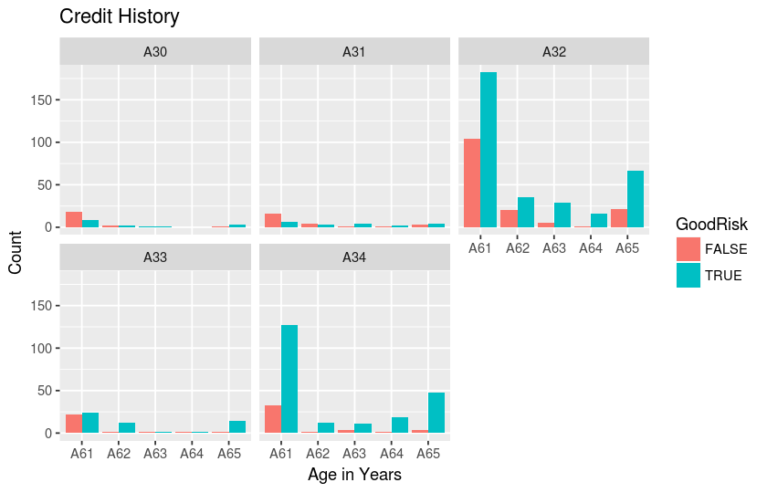

```r
# Credit history over age
ggplot(train_credit_raw) +
    ggtitle("Credit History")+
    aes(x=savingAcct, fill = GoodRisk)+
    geom_bar(position=position_dodge()) +
    facet_wrap(~credHistory)+
    xlab("Age in Years")+
    ylab("Count")+
    labs(fill = "GoodRisk")
```

### Build Model

model_fitting method takes general linear model's parameters as glm_params and the training data source as data_tr.

```r
## Base Methods

## Training
model_fitting = function(glm_params, data_tr) {
    trained_model = glm(glm_params, data=data_tr, family=binomial())
    return (trained_model)
}

## Test
compute_prediction = function(trained_model, data_test) {
    return (data_test %>% add_predictions(trained_model))
}

## Evaluation
## generating ROC using geom_roc that uses 2 aesthetics: d is the decision, m is the prediction estimate (numeric).
compute_roc = function(test_pred_this) {
    full_roc_model_this = ggplot(test_pred_this) +
        aes(d=GoodRisk, m=pred) +
        geom_roc()
    return (full_roc_model_this)
}

# sigmoid = function (x) {
#     return (1/(1+exp(-x)))
# }

# logit_threshold = function(sig) {
#     return (ifelse(sig > 0.5, 1, 0))
# }
```

#### Full Model

model_full trains glm with all possible variables

```
Call:
glm(formula = glm_params, family = binomial(), data = data_tr)

Deviance Residuals:
    Min       1Q   Median       3Q      Max
-2.6887  -0.6859   0.3589   0.6832   2.0782

Coefficients:
                            Estimate Std. Error z value Pr(>|z|)
(Intercept)                1.709e+00  1.164e+00   1.468 0.142141
CAccountStatus.L           1.192e+00  1.852e-01   6.436 1.22e-10 ***
CAccountStatus.Q           2.529e-01  2.309e-01   1.095 0.273300
CAccountStatus.C          -6.308e-02  2.703e-01  -0.233 0.815464
month                     -3.149e-02  9.913e-03  -3.177 0.001489 **
credHistoryA31            -4.943e-01  5.935e-01  -0.833 0.404977
credHistoryA32             4.131e-01  4.537e-01   0.910 0.362573
credHistoryA33             4.795e-01  4.895e-01   0.980 0.327288
credHistoryA34             1.250e+00  4.633e-01   2.698 0.006982 **
purposeA41                 1.684e+00  3.889e-01   4.331 1.49e-05 ***
purposeA410                2.228e+00  9.530e-01   2.338 0.019382 *
purposeA42                 8.221e-01  2.780e-01   2.957 0.003103 **
purposeA43                 1.080e+00  2.657e-01   4.067 4.76e-05 ***
purposeA44                 4.605e-01  8.031e-01   0.573 0.566383
purposeA45                 3.233e-01  6.056e-01   0.534 0.593450
purposeA46                 1.278e-01  4.103e-01   0.311 0.755452
purposeA48                 1.579e+01  4.785e+02   0.033 0.973672
purposeA49                 8.995e-01  3.589e-01   2.506 0.012195 *
credAmount                -1.271e-04  4.649e-05  -2.735 0.006238 **
savingAcct.L               9.523e-01  2.634e-01   3.615 0.000300 ***
savingAcct.Q              -2.596e-01  3.059e-01  -0.849 0.396067
savingAcct.C              -4.144e-01  4.084e-01  -1.015 0.310311
savingAcct^4              -6.834e-01  4.175e-01  -1.637 0.101642
employedSince.L            4.374e-01  2.982e-01   1.467 0.142389
employedSince.Q           -3.241e-01  2.841e-01  -1.141 0.253871
employedSince.C           -4.290e-01  2.448e-01  -1.753 0.079649 .
employedSince^4           -3.747e-01  1.972e-01  -1.900 0.057406 .
installmentRate           -3.530e-01  9.592e-02  -3.681 0.000233 ***
personalStatusAndSexA92    2.698e-01  4.126e-01   0.654 0.513188
personalStatusAndSexA93    8.851e-01  4.041e-01   2.190 0.028501 *
personalStatusAndSexA94    3.205e-01  4.880e-01   0.657 0.511351
```

[output cut: 13 more lines]

```
jobA173                   -5.846e-01  6.757e-01  -0.865 0.386996
jobA174                   -4.291e-01  6.837e-01  -0.628 0.530303
peopleLiableToMaintenance -4.487e-01  2.655e-01  -1.690 0.091053 .
telephoneA192              3.596e-01  2.155e-01   1.669 0.095142 .
foreignWorkersA202         1.283e+00  6.966e-01   1.841 0.065604 .
---
Signif. codes:  0 ‘***’ 0.001 ‘**’ 0.01 ‘*’ 0.05 ‘.’ 0.1 ‘ ’ 1

(Dispersion parameter for binomial family taken to be 1)

    Null deviance: 1097.86  on 899  degrees of freedom
Residual deviance:  791.67  on 851  degrees of freedom
AIC: 889.67

Number of Fisher Scoring iterations: 14
```

| PANEL | group | AUC |
| --- | --- | --- |
| 1 | -1 | 0.7545582 |

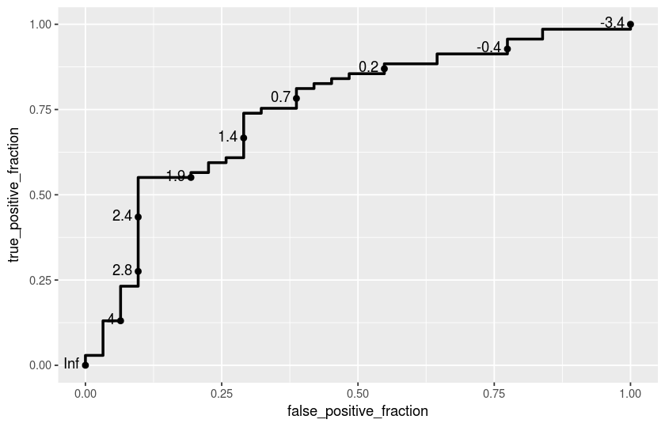

```r
model_full_params = (GoodRisk ~. -GoodRisk -outcome -id)
model_full = model_fitting(model_full_params, train_credit_raw)
print(summary(model_full))
test_model_full = compute_prediction(model_full, test_credit_raw)

roc_m_full = compute_roc(test_model_full)
roc_m_full
calc_auc(roc_m_full)
```

```r
library(MASS)
null = glm(GoodRisk ~ 1, data=train_credit_raw)
full = glm(model_full_params, data=train_credit_raw, family=binomial())
#step = stepAIC(glm(model_full_params, data=train_credit_raw, family=binomial()), trace = 1)
step = step(null, scope=list(lower=null, upper=full), direction="forward")
step$anova
```

```
Start:  AIC=1151.59
GoodRisk ~ 1

                            Df Deviance    AIC
+ CAccountStatus             3   166.43 1045.1
+ credHistory                4   177.50 1105.0
+ month                      1   179.26 1107.9
+ savingAcct                 4   182.32 1129.1
+ property                   3   183.05 1130.7
+ credAmount                 1   184.22 1132.5
+ purpose                    9   181.59 1135.5
+ employedSince              4   184.55 1140.1
+ housing                    2   185.45 1140.4
+ installmentPlans           2   186.27 1144.4
+ debators                   2   186.35 1144.8
+ age                        1   187.17 1146.7
+ foreignWorkers             1   187.29 1147.3
+ installmentRate            1   187.41 1147.9
+ personalStatusAndSex       3   187.08 1150.3
+ numOfExistingCredits       1   188.11 1151.2
<none>                           188.60 1151.6
+ telephone                  1   188.24 1151.9
+ peopleLiableToMaintenance  1   188.58 1153.5
+ residenceSince             1   188.60 1153.6
+ job                        3   188.40 1156.7

Step:  AIC=1045.07
GoodRisk ~ CAccountStatus

                            Df Deviance    AIC
+ month                      1   159.15 1006.8
+ credHistory                4   160.09 1018.1
+ credAmount                 1   162.98 1028.2
+ property                   3   162.38 1028.9
+ debators                   2   163.15 1031.1
+ foreignWorkers             1   164.88 1038.7
+ purpose                    9   162.14 1039.6
+ installmentPlans           2   164.69 1039.6
+ savingAcct                 4   164.02 1040.0
+ installmentRate            1   165.33 1041.1
```

[output cut: 257 more lines]

```
+ job                   3   136.83 936.81

Step:  AIC=930.95
GoodRisk ~ CAccountStatus + month + credHistory + purpose + debators +
    savingAcct + installmentRate + personalStatusAndSex + credAmount +
    installmentPlans + telephone + foreignWorkers + age + peopleLiableToMaintenance +
    employedSince

                       Df Deviance    AIC
<none>                      135.64 930.95
+ property              3   134.90 932.04
+ housing               2   135.21 932.11
+ numOfExistingCredits  1   135.53 932.23
+ residenceSince        1   135.61 932.72
+ job                   3   135.47 935.84
```

| Step | Df | Deviance | Resid. Df | Resid. Dev | AIC |
| --- | --- | --- | --- | --- | --- |
|  | NA | NA | 899 | 188.5989 | 1151.5943 |
| + CAccountStatus | -3 | 22.1654359 | 896 | 166.4335 | 1045.0701 |
| + month | -1 | 7.2813086 | 895 | 159.1521 | 1006.8086 |
| + credHistory | -4 | 4.9263765 | 891 | 154.2258 | 986.5099 |
| + purpose | -9 | 6.2499142 | 882 | 147.9759 | 967.2783 |
| + debators | -2 | 2.5847531 | 880 | 145.3911 | 955.4187 |
| + savingAcct | -4 | 2.7485604 | 876 | 142.6425 | 946.2417 |
| + installmentRate | -1 | 0.8660526 | 875 | 141.7765 | 942.7607 |
| ⋮ | ⋮ | ⋮ | ⋮ | ⋮ | ⋮ |
| + credAmount | -1 | 0.7894196 | 871 | 139.5092 | 936.2513 |
| + installmentPlans | -2 | 0.9062454 | 869 | 138.6029 | 934.3858 |
| + telephone | -1 | 0.5343766 | 868 | 138.0685 | 932.9092 |
| + foreignWorkers | -1 | 0.4391316 | 867 | 137.6294 | 932.0422 |
| + age | -1 | 0.4140973 | 866 | 137.2153 | 931.3302 |
| + peopleLiableToMaintenance | -1 | 0.3301526 | 865 | 136.8851 | 931.1621 |
| + employedSince | -4 | 1.2430656 | 861 | 135.6421 | 930.9518 |

## Feature Selection with Random forest

```r
library(randomForest)

fit <- randomForest(GoodRisk ~ . -GoodRisk -outcome -id, data = train_credit_raw,family=binomial(), importance=TRUE)

print(fit)
print(varImp(fit))
```

```
Call:
 randomForest(formula = GoodRisk ~ . - GoodRisk - outcome - id,      data = train_credit_raw, family = binomial(), importance = TRUE)
               Type of random forest: regression
                     Number of trees: 500
No. of variables tried at each split: 6

          Mean of squared residuals: 0.1603982
                    % Var explained: 23.46
                             Overall
CAccountStatus            35.7213445
month                     23.5452657
credHistory               13.2650184
purpose                   10.5213567
credAmount                14.2599628
savingAcct                10.2884693
employedSince              7.5947182
installmentRate            4.2643680
personalStatusAndSex       2.1106199
debators                   8.5728823
residenceSince             1.7234618
property                   5.6780745
age                        7.4136909
installmentPlans          11.3430982
housing                    2.8355121
numOfExistingCredits       2.9288887
job                        2.7580014
peopleLiableToMaintenance  1.6136721
telephone                  3.8716983
foreignWorkers             0.9117636
```

##### AIC is the relative quality of the statistical model for given data. A model with minimum AIC value has a good fit to the truth but should have few parameters. Thus, on the basis of both stepAIC and feature importance generated by Random Forest, we have to select simple model with less number of variables and minimum AIC.

## Model 1

model_1 trains glm with some of the selected features

```
Call:
glm(formula = glm_params, family = binomial(), data = data_tr)

Deviance Residuals:
    Min       1Q   Median       3Q      Max
-2.3984  -0.8449   0.4416   0.7723   2.0524

Coefficients:
                       Estimate Std. Error z value Pr(>|z|)
(Intercept)          -4.457e-01  5.683e-01  -0.784 0.432814
CAccountStatus.L      1.305e+00  1.707e-01   7.645 2.08e-14 ***
CAccountStatus.Q      1.708e-01  2.119e-01   0.806 0.420065
CAccountStatus.C      5.443e-02  2.493e-01   0.218 0.827144
month                -3.751e-02  8.614e-03  -4.354 1.34e-05 ***
credHistoryA31       -1.124e-01  5.312e-01  -0.212 0.832492
credHistoryA32        7.096e-01  4.084e-01   1.738 0.082293 .
credHistoryA33        6.783e-01  4.643e-01   1.461 0.144030
credHistoryA34        1.339e+00  4.326e-01   3.096 0.001959 **
credAmount           -4.447e-05  3.696e-05  -1.203 0.228871
installmentPlansA142  2.569e-02  4.150e-01   0.062 0.950645
installmentPlansA143  5.112e-01  2.399e-01   2.131 0.033117 *
age                   1.570e-02  7.747e-03   2.026 0.042725 *
purposeA41            1.494e+00  3.493e-01   4.276 1.90e-05 ***
purposeA410           1.816e+00  8.113e-01   2.239 0.025176 *
purposeA42            5.532e-01  2.502e-01   2.211 0.027022 *
purposeA43            9.187e-01  2.410e-01   3.812 0.000138 ***
purposeA44            2.718e-01  7.531e-01   0.361 0.718118
purposeA45            6.739e-03  5.405e-01   0.012 0.990053
purposeA46           -2.504e-01  3.855e-01  -0.649 0.516089
purposeA48            1.498e+01  5.234e+02   0.029 0.977173
purposeA49            7.998e-01  3.289e-01   2.431 0.015037 *
---
Signif. codes:  0 ‘***’ 0.001 ‘**’ 0.01 ‘*’ 0.05 ‘.’ 0.1 ‘ ’ 1

(Dispersion parameter for binomial family taken to be 1)

    Null deviance: 1097.86  on 899  degrees of freedom
Residual deviance:  876.43  on 878  degrees of freedom
AIC: 920.43

Number of Fisher Scoring iterations: 14
```

| PANEL | group | AUC |
| --- | --- | --- |
| 1 | -1 | 0.7671809 |

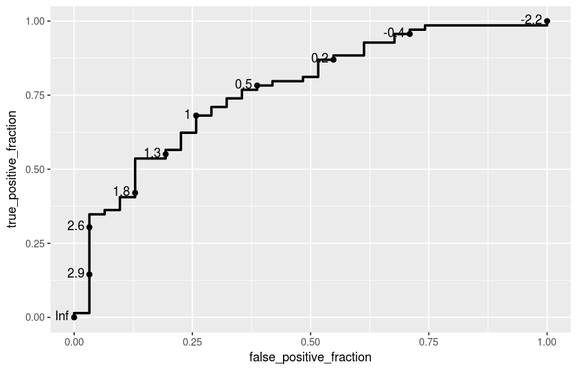

```r
model_1 = model_fitting((GoodRisk ~ CAccountStatus + month + credHistory + credAmount +installmentPlans +
                         age+ purpose ),
                        train_credit_raw)
print(summary(model_1))
test_model_1 = compute_prediction(model_1, test_credit_raw)

roc_m_1 = compute_roc(test_model_1)
roc_m_1
calc_auc(roc_m_1)
```

## Model 2

model_2 trains glm with some of the selected features

```
Call:
glm(formula = glm_params, family = binomial(), data = data_tr)

Deviance Residuals:
    Min       1Q   Median       3Q      Max
-2.4596  -0.8357   0.4303   0.7530   2.0697

Coefficients:
                       Estimate Std. Error z value Pr(>|z|)
(Intercept)          -5.897e-01  5.728e-01  -1.029 0.303245
CAccountStatus.L      1.341e+00  1.724e-01   7.776 7.50e-15 ***
CAccountStatus.Q      1.766e-01  2.130e-01   0.829 0.407077
CAccountStatus.C      2.758e-03  2.515e-01   0.011 0.991250
month                -3.772e-02  8.697e-03  -4.337 1.45e-05 ***
credHistoryA31       -9.267e-02  5.378e-01  -0.172 0.863195
credHistoryA32        7.442e-01  4.090e-01   1.820 0.068797 .
credHistoryA33        7.359e-01  4.646e-01   1.584 0.113158
credHistoryA34        1.403e+00  4.344e-01   3.230 0.001239 **
credAmount           -3.474e-05  3.721e-05  -0.934 0.350526
installmentPlansA142  8.107e-02  4.191e-01   0.193 0.846614
installmentPlansA143  5.687e-01  2.436e-01   2.335 0.019544 *
age                   1.637e-02  7.811e-03   2.096 0.036124 *
purposeA41            1.435e+00  3.496e-01   4.103 4.07e-05 ***
purposeA410           2.005e+00  8.238e-01   2.434 0.014947 *
purposeA42            5.803e-01  2.531e-01   2.293 0.021843 *
purposeA43            8.844e-01  2.451e-01   3.609 0.000308 ***
purposeA44            2.983e-01  7.573e-01   0.394 0.693630
purposeA45           -3.700e-02  5.557e-01  -0.067 0.946917
purposeA46           -2.426e-01  3.879e-01  -0.625 0.531699
purposeA48            1.505e+01  5.212e+02   0.029 0.976971
purposeA49            8.450e-01  3.324e-01   2.542 0.011018 *
debatorsA102         -9.088e-01  4.165e-01  -2.182 0.029106 *
debatorsA103          1.244e+00  4.773e-01   2.607 0.009144 **
---
Signif. codes:  0 ‘***’ 0.001 ‘**’ 0.01 ‘*’ 0.05 ‘.’ 0.1 ‘ ’ 1

(Dispersion parameter for binomial family taken to be 1)

    Null deviance: 1097.86  on 899  degrees of freedom
Residual deviance:  862.72  on 876  degrees of freedom
AIC: 910.72

Number of Fisher Scoring iterations: 14
```

| PANEL | group | AUC |
| --- | --- | --- |
| 1 | -1 | 0.7568957 |

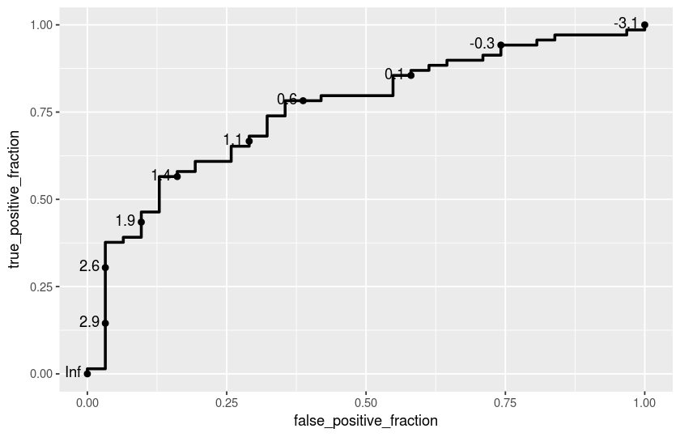

```r
model_2 = model_fitting((GoodRisk ~ CAccountStatus + month + credHistory + credAmount +installmentPlans
                         +age+ purpose + debators),
                        train_credit_raw)
print(summary(model_2))
test_model_2 = compute_prediction(model_2, test_credit_raw)

roc_m_2 = compute_roc(test_model_2)
roc_m_2
calc_auc(roc_m_2)
```

## Model 3

model_3 trains glm with some of the selected features

```
Call:
glm(formula = glm_params, family = binomial(), data = data_tr)

Deviance Residuals:
    Min       1Q   Median       3Q      Max
-2.7340  -0.7871   0.4194   0.7402   2.0385

Coefficients:
                       Estimate Std. Error z value Pr(>|z|)
(Intercept)          -1.071e-01  5.956e-01  -0.180 0.857276
CAccountStatus.L      1.248e+00  1.764e-01   7.070 1.54e-12 ***
CAccountStatus.Q      1.914e-01  2.170e-01   0.882 0.377621
CAccountStatus.C     -1.167e-01  2.576e-01  -0.453 0.650483
month                -3.989e-02  8.886e-03  -4.489 7.16e-06 ***
credHistoryA31       -2.971e-01  5.483e-01  -0.542 0.587930
credHistoryA32        6.145e-01  4.136e-01   1.486 0.137316
credHistoryA33        6.323e-01  4.676e-01   1.352 0.176309
credHistoryA34        1.321e+00  4.396e-01   3.006 0.002646 **
credAmount           -3.684e-05  3.788e-05  -0.973 0.330779
installmentPlansA142  1.053e-01  4.275e-01   0.246 0.805543
installmentPlansA143  6.351e-01  2.463e-01   2.578 0.009929 **
age                   1.578e-02  8.005e-03   1.972 0.048624 *
purposeA41            1.462e+00  3.589e-01   4.074 4.63e-05 ***
purposeA410           2.020e+00  8.230e-01   2.454 0.014111 *
purposeA42            6.303e-01  2.578e-01   2.444 0.014506 *
purposeA43            9.518e-01  2.506e-01   3.798 0.000146 ***
purposeA44            2.242e-01  7.575e-01   0.296 0.767197
purposeA45            6.731e-02  5.755e-01   0.117 0.906898
purposeA46           -2.331e-01  3.923e-01  -0.594 0.552400
purposeA48            1.520e+01  4.993e+02   0.030 0.975721
purposeA49            9.231e-01  3.394e-01   2.720 0.006528 **
debatorsA102         -8.457e-01  4.212e-01  -2.008 0.044643 *
debatorsA103          1.418e+00  4.828e-01   2.937 0.003319 **
savingAcct.L          8.888e-01  2.506e-01   3.546 0.000391 ***
savingAcct.Q         -2.570e-01  2.969e-01  -0.866 0.386752
savingAcct.C         -3.203e-01  3.928e-01  -0.816 0.414734
savingAcct^4         -4.678e-01  4.028e-01  -1.161 0.245449
---
Signif. codes:  0 ‘***’ 0.001 ‘**’ 0.01 ‘*’ 0.05 ‘.’ 0.1 ‘ ’ 1

(Dispersion parameter for binomial family taken to be 1)

    Null deviance: 1097.86  on 899  degrees of freedom
Residual deviance:  842.37  on 872  degrees of freedom
AIC: 898.37

Number of Fisher Scoring iterations: 14
```

| PANEL | group | AUC |
| --- | --- | --- |
| 1 | -1 | 0.7480131 |

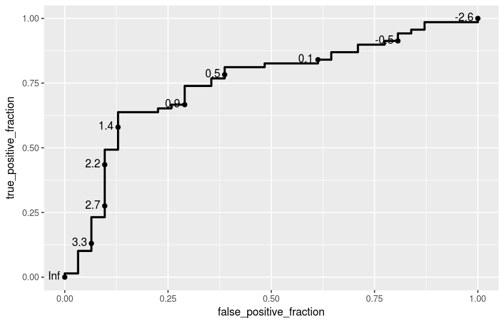

```r
model_3 = model_fitting((GoodRisk ~ CAccountStatus + month + credHistory + credAmount +installmentPlans+age
                         + purpose + debators + savingAcct ), train_credit_raw)
print(summary(model_3))
test_model_3 = compute_prediction(model_3, test_credit_raw)

roc_m_3 = compute_roc(test_model_3)
roc_m_3
calc_auc(roc_m_3)
```

## Model 4

model_4 trains glm with some of the selected features

```
Call:
glm(formula = glm_params, family = binomial(), data = data_tr)

Deviance Residuals:
    Min       1Q   Median       3Q      Max
-2.6579  -0.7338   0.3927   0.7096   2.2754

Coefficients:
                         Estimate Std. Error z value Pr(>|z|)
(Intercept)             1.647e+00  7.600e-01   2.166 0.030273 *
CAccountStatus.L        1.257e+00  1.832e-01   6.860 6.87e-12 ***
CAccountStatus.Q        1.819e-01  2.207e-01   0.824 0.409957
CAccountStatus.C       -1.307e-01  2.610e-01  -0.501 0.616477
housingA152            -2.574e-01  5.371e-01  -0.479 0.631800
housingA153            -7.016e-01  1.089e+00  -0.644 0.519369
propertyA122           -1.352e+00  5.325e-01  -2.539 0.011113 *
propertyA123           -9.206e-01  5.075e-01  -1.814 0.069695 .
propertyA124           -1.067e+00  9.410e-01  -1.134 0.256645
month                  -1.154e-01  2.880e-02  -4.006 6.18e-05 ***
credHistoryA31         -2.194e-01  5.756e-01  -0.381 0.703072
credHistoryA32          6.106e-01  4.316e-01   1.415 0.157080
credHistoryA33          5.677e-01  4.853e-01   1.170 0.242021
credHistoryA34          1.378e+00  4.560e-01   3.022 0.002507 **
credAmount              6.547e-06  6.039e-05   0.108 0.913662
purposeA41              4.108e+00  1.017e+00   4.038 5.39e-05 ***
purposeA410             2.096e+00  1.356e+00   1.546 0.122129
purposeA42              1.056e+00  4.399e-01   2.402 0.016312 *
purposeA43              5.836e-01  3.794e-01   1.538 0.124013
purposeA44             -1.300e+00  1.255e+00  -1.036 0.300171
purposeA45             -2.437e-01  8.463e-01  -0.288 0.773406
purposeA46             -4.903e-01  5.691e-01  -0.861 0.389014
purposeA48              1.590e+01  7.058e+02   0.023 0.982025
purposeA49              1.150e+00  5.487e-01   2.095 0.036133 *
installmentPlansA142    2.395e-02  4.409e-01   0.054 0.956690
installmentPlansA143    5.599e-01  2.545e-01   2.200 0.027780 *
debatorsA102           -7.103e-01  4.532e-01  -1.567 0.117056
debatorsA103            1.365e+00  5.034e-01   2.711 0.006712 **
savingAcct.L            8.940e-01  2.572e-01   3.476 0.000509 ***
savingAcct.Q           -2.951e-01  3.022e-01  -0.976 0.328865
savingAcct.C           -3.094e-01  4.027e-01  -0.768 0.442335
```

[output cut: 10 more lines]

```
credAmount:purposeA44   9.837e-04  6.441e-04   1.527 0.126734
credAmount:purposeA45   1.572e-04  1.976e-04   0.796 0.426205
credAmount:purposeA46   1.719e-04  1.330e-04   1.292 0.196305
credAmount:purposeA48  -7.122e-04  4.019e-01  -0.002 0.998586
credAmount:purposeA49  -4.708e-05  1.096e-04  -0.430 0.667375
---
Signif. codes:  0 ‘***’ 0.001 ‘**’ 0.01 ‘*’ 0.05 ‘.’ 0.1 ‘ ’ 1

(Dispersion parameter for binomial family taken to be 1)

    Null deviance: 1097.86  on 899  degrees of freedom
Residual deviance:  808.29  on 854  degrees of freedom
AIC: 900.29

Number of Fisher Scoring iterations: 14
```

| PANEL | group | AUC |
| --- | --- | --- |
| 1 | -1 | 0.7582983 |

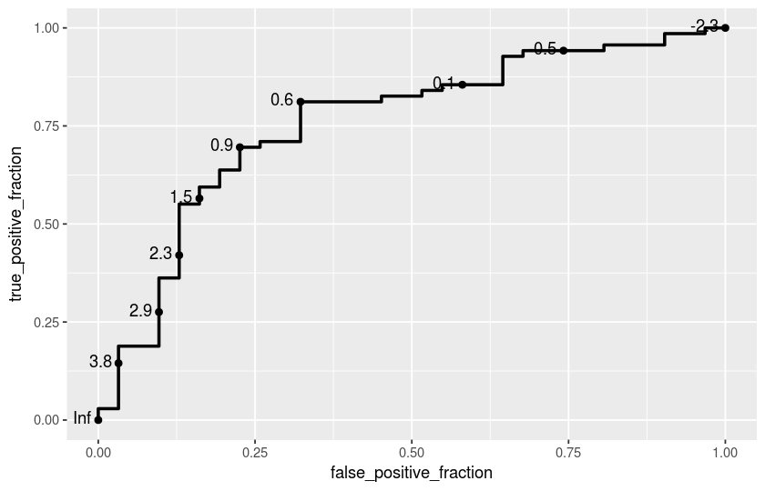

```r
model_4 = model_fitting((GoodRisk ~ CAccountStatus + (housing + property) * month + credHistory + credAmount * purpose +installmentPlans
                          + debators + savingAcct), train_credit_raw)
print(summary(model_4))
test_model_4 = compute_prediction(model_4, test_credit_raw)

roc_m_4 = compute_roc(test_model_4)
roc_m_4
calc_auc(roc_m_4)
```

### Model 5

```
Call:
glm(formula = glm_params, family = binomial(), data = data_tr)

Deviance Residuals:
    Min       1Q   Median       3Q      Max
-2.6465  -0.7727   0.4158   0.7268   2.1606

Coefficients:
                       Estimate Std. Error z value Pr(>|z|)
(Intercept)           5.442e-03  6.212e-01   0.009 0.993011
CAccountStatus.L      1.230e+00  1.775e-01   6.929 4.23e-12 ***
CAccountStatus.Q      1.882e-01  2.177e-01   0.864 0.387397
CAccountStatus.C     -1.206e-01  2.583e-01  -0.467 0.640496
month                -3.682e-02  9.092e-03  -4.049 5.14e-05 ***
credHistoryA31       -2.747e-01  5.538e-01  -0.496 0.619906
credHistoryA32        5.744e-01  4.151e-01   1.384 0.166477
credHistoryA33        5.998e-01  4.696e-01   1.277 0.201491
credHistoryA34        1.285e+00  4.404e-01   2.918 0.003523 **
credAmount           -2.729e-05  3.830e-05  -0.713 0.476111
installmentPlansA142  2.762e-02  4.298e-01   0.064 0.948758
installmentPlansA143  5.941e-01  2.487e-01   2.389 0.016910 *
age                   1.934e-02  8.393e-03   2.304 0.021226 *
purposeA41            1.551e+00  3.649e-01   4.250 2.14e-05 ***
purposeA410           2.054e+00  8.123e-01   2.529 0.011441 *
purposeA42            6.618e-01  2.604e-01   2.542 0.011027 *
purposeA43            9.135e-01  2.519e-01   3.626 0.000287 ***
purposeA44            1.814e-01  7.615e-01   0.238 0.811733
purposeA45            8.674e-02  5.801e-01   0.150 0.881142
purposeA46           -7.861e-02  4.010e-01  -0.196 0.844604
purposeA48            1.513e+01  5.063e+02   0.030 0.976157
purposeA49            8.766e-01  3.416e-01   2.566 0.010292 *
debatorsA102         -8.263e-01  4.251e-01  -1.944 0.051905 .
debatorsA103          1.364e+00  4.923e-01   2.771 0.005595 **
savingAcct.L          8.624e-01  2.529e-01   3.409 0.000651 ***
savingAcct.Q         -2.835e-01  2.983e-01  -0.950 0.341918
savingAcct.C         -2.544e-01  3.980e-01  -0.639 0.522602
savingAcct^4         -4.568e-01  4.042e-01  -1.130 0.258442
propertyA122         -3.356e-01  2.571e-01  -1.306 0.191714
propertyA123         -2.220e-01  2.410e-01  -0.921 0.357035
propertyA124         -6.555e-01  3.116e-01  -2.104 0.035371 *
---
Signif. codes:  0 ‘***’ 0.001 ‘**’ 0.01 ‘*’ 0.05 ‘.’ 0.1 ‘ ’ 1

(Dispersion parameter for binomial family taken to be 1)

    Null deviance: 1097.86  on 899  degrees of freedom
Residual deviance:  837.63  on 869  degrees of freedom
AIC: 899.63

Number of Fisher Scoring iterations: 14
```

| PANEL | group | AUC |
| --- | --- | --- |
| 1 | -1 | 0.7447405 |

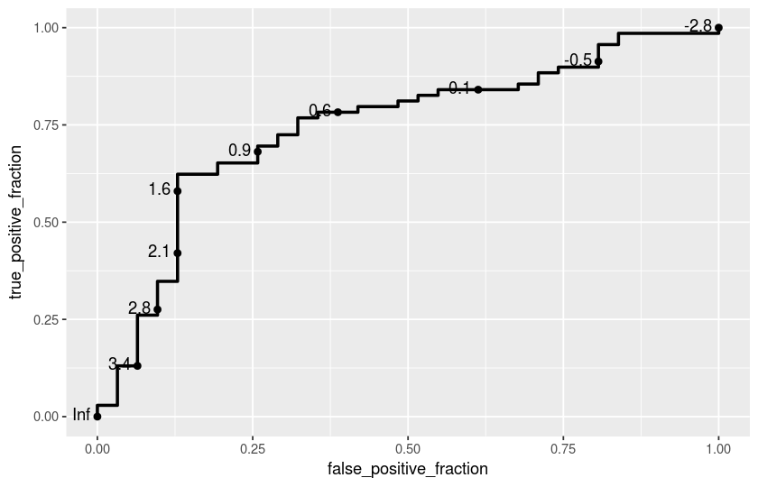

```r
model_5 = model_fitting((GoodRisk ~ CAccountStatus + month + credHistory + credAmount +installmentPlans+age
                         + purpose + debators + savingAcct+ property), train_credit_raw)
print(summary(model_5))
test_model_5 = compute_prediction(model_5, test_credit_raw)

roc_m_5 = compute_roc(test_model_5)
roc_m_5
calc_auc(roc_m_5)
```

## Observation from graph

### threshold

Computing threshold taking the range of values between minimum and maximum of predicted logits with the interval of 0.1

```r
thresholds = seq(min(test_model_4$pred), max(test_model_4$pred), 0.1)
thresholds
```

1. -2.27868353805449

2. -2.17868353805449

3. -2.07868353805449

4. -1.97868353805449

5. -1.87868353805449

6. -1.77868353805449

7. -1.67868353805449

8. -1.57868353805449

9. -1.47868353805449

10. -1.37868353805449

11. -1.27868353805449

12. -1.17868353805449

13. -1.07868353805449

14. -0.978683538054491

15. -0.878683538054491

16. -0.778683538054491

17. -0.678683538054491

18. -0.578683538054491

19. -0.478683538054491

20. -0.378683538054491

21. -0.278683538054491

22. -0.178683538054491

23. -0.0786835380544906

24. 0.0213164619455095

25. 0.12131646194551

26. 0.221316461945509

27. 0.321316461945509

28. 0.421316461945509

29. 0.52131646194551

30. 0.62131646194551

31. 0.721316461945509

32. 0.821316461945509

33. 0.921316461945509

34. 1.02131646194551

35. 1.12131646194551

36. 1.22131646194551

37. 1.32131646194551

38. 1.42131646194551

39. 1.52131646194551

40. 1.62131646194551

41. 1.72131646194551

42. 1.82131646194551

43. 1.92131646194551

44. 2.02131646194551

45. 2.12131646194551

46. 2.22131646194551

47. 2.32131646194551

48. 2.42131646194551

49. 2.52131646194551

50. 2.62131646194551

51. 2.72131646194551

52. 2.82131646194551

53. 2.92131646194551

54. 3.02131646194551

55. 3.12131646194551

56. 3.22131646194551

57. 3.32131646194551

58. 3.42131646194551

59. 3.52131646194551

60. 3.62131646194551

61. 3.72131646194551

62. 3.82131646194551

63. 3.92131646194551

64. 4.02131646194551

65. 4.12131646194551

66. 4.22131646194551

67. 4.32131646194551

68. 4.42131646194551

69. 4.52131646194551

70. 4.62131646194551

71. 4.72131646194551

72. 4.82131646194551

73. 4.92131646194551

74. 5.02131646194551

75. 5.12131646194551

76. 5.22131646194551

77. 5.32131646194551

78. 5.42131646194551

79. 5.52131646194551

80. 5.62131646194551

81. 5.72131646194551

82. 5.82131646194551

83. 5.92131646194551

84. 6.02131646194551

85. 6.12131646194551

86. 6.22131646194551

87. 6.32131646194551

88. 6.42131646194551

89. 6.52131646194551

90. 6.62131646194551

91. 6.72131646194551

92. 6.82131646194551

93. 6.92131646194551

94. 7.02131646194551

95. 7.12131646194551

96. 7.22131646194551

97. 7.32131646194551

98. 7.42131646194551

99. 7.52131646194551

100. 7.62131646194551

101. 7.72131646194551

102. 7.82131646194551

103. 7.92131646194551

104. 8.02131646194551

105. 8.12131646194551

106. 8.22131646194551

107. 8.32131646194551

108. 8.42131646194551

109. 8.52131646194551

110. 8.62131646194551

111. 8.72131646194551

112. 8.82131646194551

113. 8.92131646194551

114. 9.02131646194551

115. 9.12131646194551

116. 9.22131646194551

117. 9.32131646194551

118. 9.42131646194551

119. 9.52131646194551

120. 9.62131646194551

121. 9.72131646194551

122. 9.82131646194551

123. 9.92131646194551

124. 10.0213164619455

125. 10.1213164619455

126. 10.2213164619455

127. 10.3213164619455

128. 10.4213164619455

129. 10.5213164619455

130. 10.6213164619455

131. 10.7213164619455

132. 10.8213164619455

133. 10.9213164619455

134. 11.0213164619455

135. 11.1213164619455

136. 11.2213164619455

137. 11.3213164619455

138. 11.4213164619455

139. 11.5213164619455

140. 11.6213164619455

141. 11.7213164619455

142. 11.8213164619455

143. 11.9213164619455

144. 12.0213164619455

145. 12.1213164619455

146. 12.2213164619455

147. 12.3213164619455

148. 12.4213164619455

149. 12.5213164619455

150. 12.6213164619455

151. 12.7213164619455

152. 12.8213164619455

153. 12.9213164619455

154. 13.0213164619455

155. 13.1213164619455

156. 13.2213164619455

157. 13.3213164619455

158. 13.4213164619455

159. 13.5213164619455

160. 13.6213164619455

161. 13.7213164619455

162. 13.8213164619455

163. 13.9213164619455

164. 14.0213164619455

165. 14.1213164619455

166. 14.2213164619455

167. 14.3213164619455

168. 14.4213164619455

169. 14.5213164619455

170. 14.6213164619455

171. 14.7213164619455

172. 14.8213164619455

173. 14.9213164619455

174. 15.0213164619455

175. 15.1213164619455

176. 15.2213164619455

177. 15.3213164619455

178. 15.4213164619455

179. 15.5213164619455

180. 15.6213164619455

181. 15.7213164619455

182. 15.8213164619455

183. 15.9213164619455

184. 16.0213164619455

## Cost

1. convert the numeric score of predictions from the regression output into binary outcomes as TRUE or FALSE by comparing with the threshold
2. computing the cost of overall test set using each of these thresholds

```r
costs = function(threshold) {

   test_model_4$sample_outcome = ifelse(test_model_4$pred > threshold, TRUE, FALSE)
   totalcosts= sum((test_model_4$GoodRisk == "TRUE" & test_model_4$sample_outcome == "FALSE") * 1,
                                    (test_model_4$GoodRisk==FALSE & test_model_4$sample_outcome==TRUE)*5)

    return(totalcosts)

}
```

```r
totalcost=apply(data.frame(thresholds), 1, function(x){ costs(x)})
threshold_cost=data.frame(thresholds, totalcost)
head(threshold_cost)
```

| thresholds | totalcost |
| --- | --- |
| -2.278684 | 150 |
| -2.178684 | 150 |
| -2.078684 | 150 |
| -1.978684 | 151 |
| -1.878684 | 151 |
| -1.778684 | 141 |

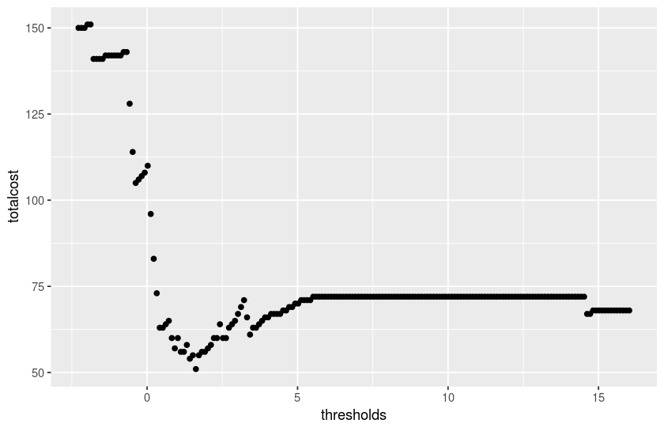

```r
ggplot(threshold_cost) +
    aes(x=thresholds, y=totalcost) +
    geom_point()
```

finding the value of threshold having minimum cost.

```r
threshold_mincost=filter(threshold_cost, totalcost==min(totalcost))
threshold_mincost
```

| thresholds | totalcost |
| --- | --- |
| 1.621316 | 51 |

There can be multiple thresholds giving minimum cost. Thus, we select first threshold as minimum threshold

```r
selected_threshold=threshold_mincost$thresholds[1]
selected_threshold
```

1.62131646194551

### calculate precision and recall

```r
recall_precision=function(thresholds){
    dataf = dplyr::select(test_model_4, GoodRisk, pred)
    dataf$sample_outcome = ifelse(dataf$pred > thresholds, TRUE, FALSE)

    TP=sum(dataf$GoodRisk==TRUE & dataf$sample_outcome==TRUE)
    TN=sum(dataf$GoodRisk==FALSE & dataf$sample_outcome==FALSE)
    FP=sum(dataf$GoodRisk==FALSE & dataf$sample_outcome==TRUE)
    FN=sum(dataf$GoodRisk==TRUE & dataf$sample_outcome==FALSE)
    Recall=TP / sum(TP,FN)
    Precision=TP / sum(TP,FP)
    PR=data.frame(Recall, Precision)
    return(PR)

}
recall_precision(selected_threshold)
```

| Recall | Precision |
| --- | --- |
| 0.5507246 | 0.9047619 |

Precision and recall for threshold that gives minimum cost and other two thresholds

```r
th<-seq(selected_threshold-0.1,selected_threshold+0.1,0.1)
next_thresholds=apply(data.frame(th), 1, function(x){ recall_precision(x)})
P_R=data.frame(th, next_thresholds)
P_R
```

| th | Recall | Precision | Recall.1 | Precision.1 | Recall.2 | Precision.2 |
| --- | --- | --- | --- | --- | --- | --- |
| 1.521316 | 0.5652174 | 0.8863636 | 0.5507246 | 0.9047619 | 0.4927536 | 0.8947368 |
| 1.621316 | 0.5652174 | 0.8863636 | 0.5507246 | 0.9047619 | 0.4927536 | 0.8947368 |
| 1.721316 | 0.5652174 | 0.8863636 | 0.5507246 | 0.9047619 | 0.4927536 | 0.8947368 |

## Direct Descrimination

protected features:

1. non single women
2. foreign workers

check the selected best model use the protected features?

```r
summary(model_4)
```

```
Call:
glm(formula = glm_params, family = binomial(), data = data_tr)

Deviance Residuals:
    Min       1Q   Median       3Q      Max
-2.6579  -0.7338   0.3927   0.7096   2.2754

Coefficients:
                         Estimate Std. Error z value Pr(>|z|)
(Intercept)             1.647e+00  7.600e-01   2.166 0.030273 *
CAccountStatus.L        1.257e+00  1.832e-01   6.860 6.87e-12 ***
CAccountStatus.Q        1.819e-01  2.207e-01   0.824 0.409957
CAccountStatus.C       -1.307e-01  2.610e-01  -0.501 0.616477
housingA152            -2.574e-01  5.371e-01  -0.479 0.631800
housingA153            -7.016e-01  1.089e+00  -0.644 0.519369
propertyA122           -1.352e+00  5.325e-01  -2.539 0.011113 *
propertyA123           -9.206e-01  5.075e-01  -1.814 0.069695 .
propertyA124           -1.067e+00  9.410e-01  -1.134 0.256645
month                  -1.154e-01  2.880e-02  -4.006 6.18e-05 ***
credHistoryA31         -2.194e-01  5.756e-01  -0.381 0.703072
credHistoryA32          6.106e-01  4.316e-01   1.415 0.157080
credHistoryA33          5.677e-01  4.853e-01   1.170 0.242021
credHistoryA34          1.378e+00  4.560e-01   3.022 0.002507 **
credAmount              6.547e-06  6.039e-05   0.108 0.913662
purposeA41              4.108e+00  1.017e+00   4.038 5.39e-05 ***
purposeA410             2.096e+00  1.356e+00   1.546 0.122129
purposeA42              1.056e+00  4.399e-01   2.402 0.016312 *
purposeA43              5.836e-01  3.794e-01   1.538 0.124013
purposeA44             -1.300e+00  1.255e+00  -1.036 0.300171
purposeA45             -2.437e-01  8.463e-01  -0.288 0.773406
purposeA46             -4.903e-01  5.691e-01  -0.861 0.389014
purposeA48              1.590e+01  7.058e+02   0.023 0.982025
purposeA49              1.150e+00  5.487e-01   2.095 0.036133 *
installmentPlansA142    2.395e-02  4.409e-01   0.054 0.956690
installmentPlansA143    5.599e-01  2.545e-01   2.200 0.027780 *
debatorsA102           -7.103e-01  4.532e-01  -1.567 0.117056
debatorsA103            1.365e+00  5.034e-01   2.711 0.006712 **
savingAcct.L            8.940e-01  2.572e-01   3.476 0.000509 ***
savingAcct.Q           -2.951e-01  3.022e-01  -0.976 0.328865
savingAcct.C           -3.094e-01  4.027e-01  -0.768 0.442335
```

[output cut: 10 more lines]

```
credAmount:purposeA44   9.837e-04  6.441e-04   1.527 0.126734
credAmount:purposeA45   1.572e-04  1.976e-04   0.796 0.426205
credAmount:purposeA46   1.719e-04  1.330e-04   1.292 0.196305
credAmount:purposeA48  -7.122e-04  4.019e-01  -0.002 0.998586
credAmount:purposeA49  -4.708e-05  1.096e-04  -0.430 0.667375
---
Signif. codes:  0 ‘***’ 0.001 ‘**’ 0.01 ‘*’ 0.05 ‘.’ 0.1 ‘ ’ 1

(Dispersion parameter for binomial family taken to be 1)

    Null deviance: 1097.86  on 899  degrees of freedom
Residual deviance:  808.29  on 854  degrees of freedom
AIC: 900.29

Number of Fisher Scoring iterations: 14
```

## Indirect Discrimination

### chi-square test

Null Hypothesis: protected features are independent of other features of the model

Alternative Hypothesis: protected features are not independent of other features of the model

level of significance: 0.05

if p-value(>0.05) then we do not reject null hypothesis i.e protected features are independent of other features of the model.

### Correlation between Protected features and CAccountStatus

```r
chi_Squared_test=function(other_features){
    contingency_table_foreignWorkers = table(credit_raw$foreignWorkers, other_features)
    print(contingency_table_foreignWorkers)
    chi_squared_foreignWorkers=chisq.test(contingency_table_foreignWorkers)
    print(chi_squared_foreignWorkers)


    contingency_table_nonSingleWomen = table(credit_raw$personalStatusAndSex=='A92', other_features)
    print(contingency_table_nonSingleWomen)
    chi_squared_nonSingleWomen=chisq.test(contingency_table_nonSingleWomen)
    return(chi_squared_nonSingleWomen)




}
```

```r
chi_Squared_test(credit_raw$CAccountStatus)
```

```
      other_features
       A11 A12 A13 A14
  A201 259 264  59 381
  A202  15   5   4  13

	Pearson's Chi-squared test

data:  contingency_table_foreignWorkers
X-squared = 6.3991, df = 3, p-value = 0.09373

       other_features
        A11 A12 A13 A14
  FALSE 186 183  43 278
  TRUE   88  86  20 116
```

```
	Pearson's Chi-squared test

data:  contingency_table_nonSingleWomen
X-squared = 0.74188, df = 3, p-value = 0.8633
```

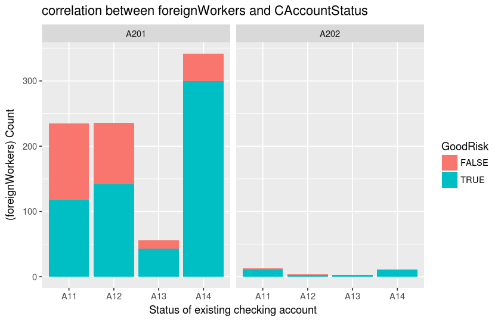

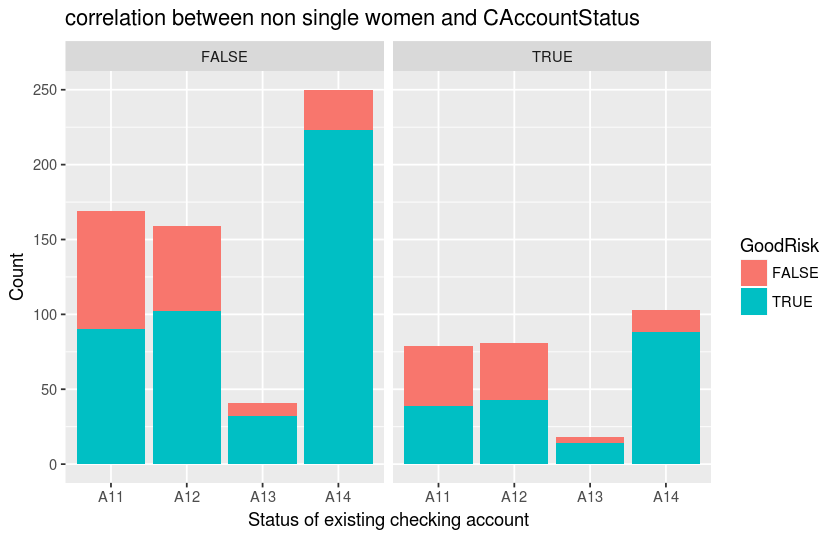

```r
ggplot(train_credit_raw) +
    ggtitle("correlation between foreignWorkers and CAccountStatus")+
    aes(x=CAccountStatus, fill = GoodRisk)+
    geom_bar() +
    facet_wrap(~foreignWorkers)+
    xlab("Status of existing checking account")+
    ylab("(foreignWorkers) Count")+
    labs(fill = "GoodRisk")

ggplot(train_credit_raw) +
    ggtitle("correlation between non single women and CAccountStatus")+
    aes(x=CAccountStatus, fill = GoodRisk)+
    geom_bar() +
    facet_wrap(~personalStatusAndSex=='A92')+
    xlab("Status of existing checking account")+
    ylab("Count")+
    labs(fill = "GoodRisk")
```

#### Observation

We apply the chisq.test function to the contingency table and found the p-value to be 0.09373 for foreignWorkers and 0.8633 for non single Women.

We observed the p-value for foreignWorkers to be 0.09373 (> 0.05) and 0.8633 (> 0.05) for non single Women. For each of the cases, we do not have enough statistical evidence to reject the null hypothesis. That's why we state that both foreignWorkers and non single women are independent of the Status of existing checking account with a 0.05 level of significance.

### Correlation between Protected features and Housing

```
      other_features
       A151 A152 A153
  A201  170  685  108
  A202    9   28    0

	Pearson's Chi-squared test

data:  contingency_table_foreignWorkers
X-squared = 5.1386, df = 2, p-value = 0.07659

       other_features
        A151 A152 A153
  FALSE   84  517   89
  TRUE    95  196   19
```

```
	Pearson's Chi-squared test

data:  contingency_table_nonSingleWomen
X-squared = 53.955, df = 2, p-value = 1.922e-12
```

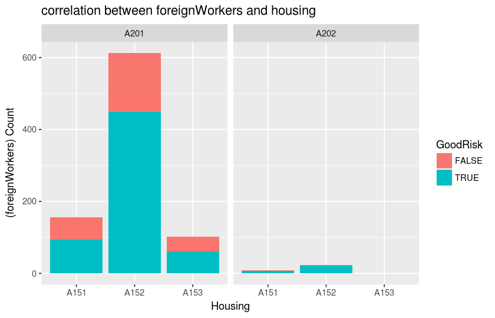

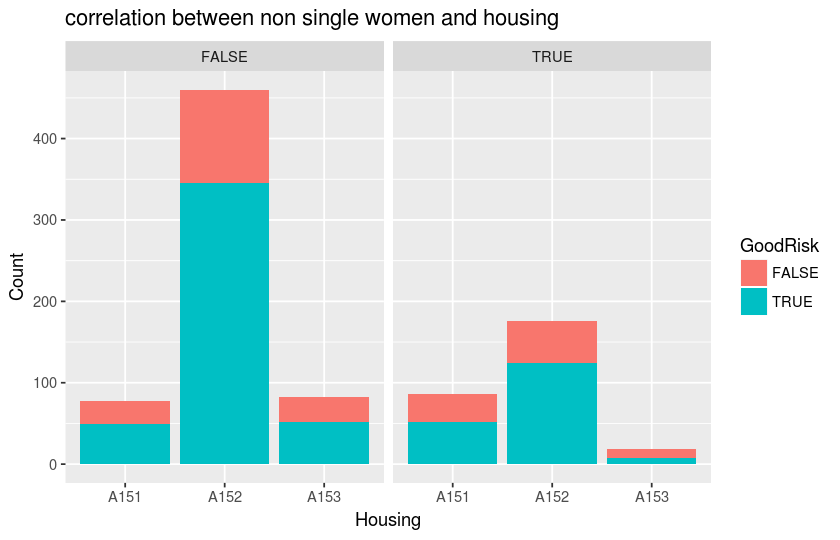

```r
chi_Squared_test(credit_raw$housing)

ggplot(train_credit_raw) +
    ggtitle("correlation between foreignWorkers and housing")+
    aes(x=housing, fill=GoodRisk)+
    geom_bar() +
    facet_wrap(~foreignWorkers)+
    xlab("Housing")+
    ylab("(foreignWorkers) Count")


ggplot(train_credit_raw) +
    ggtitle("correlation between non single women and housing")+
    aes(x=housing, fill=GoodRisk)+
    geom_bar() +
    facet_wrap(~personalStatusAndSex=='A92')+
    xlab("Housing")+
    ylab("Count")
```

### Observation

We apply the chisq.test function to the contingency table and found the p-value to be 0.07659 for foreignWorkers and 1.922e-12 for non single Women.

We observed the p-value for foreignWorkers to be 0.07659 (> 0.05) and 1.922e-12 (< 0.05) for non single Women. For foreignWorkers, we do not have enough statistical evidence to reject the null hypothesis but we can reject the null hypothesis for non single womens. That's why we state that the foreignWorkers is independent but non single womens is not independent of the housing with a 0.05 level of significance.

### Correlation between Protected features and Property

```
      other_features
       A121 A122 A123 A124
  A201  262  220  329  152
  A202   20   12    3    2

	Pearson's Chi-squared test

data:  contingency_table_foreignWorkers
X-squared = 20.297, df = 3, p-value = 0.0001473

       other_features
        A121 A122 A123 A124
  FALSE  193  153  223  121
  TRUE    89   79  109   33
```

```
	Pearson's Chi-squared test

data:  contingency_table_nonSingleWomen
X-squared = 8.1678, df = 3, p-value = 0.04267
```

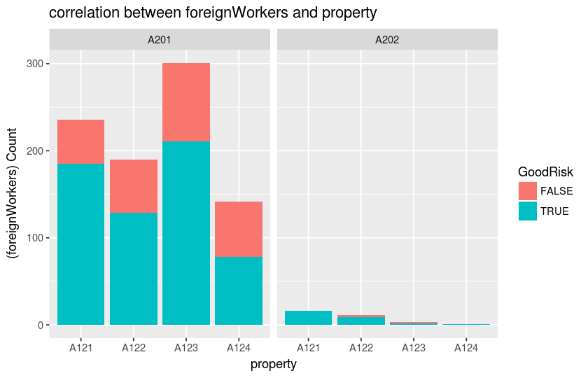

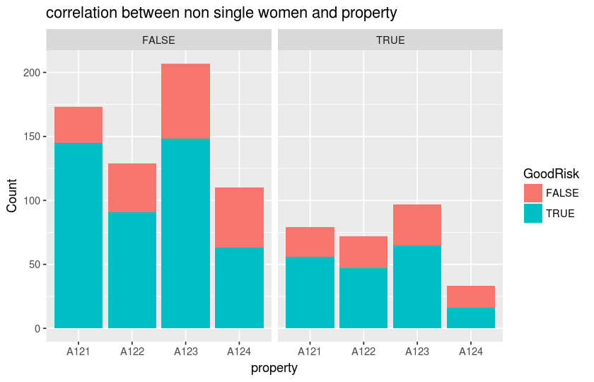

```r
chi_Squared_test(credit_raw$property)


ggplot(train_credit_raw) +
    ggtitle("correlation between foreignWorkers and property")+
    aes(x=property, fill=GoodRisk)+
    geom_bar() +
    facet_wrap(~foreignWorkers)+
    xlab("property")+
    ylab("(foreignWorkers) Count")


ggplot(train_credit_raw) +
    ggtitle("correlation between non single women and property")+
    aes(x=property, fill=GoodRisk)+
    geom_bar() +
    facet_wrap(~personalStatusAndSex=='A92')+
    xlab("property")+
    ylab("Count")
```

### Observation

We apply the chisq.test function to the contingency table and found the p-value to be 0.0001473for foreignWorkers and 0.04267 for non single Women.

We observed the p-value for foreignWorkers to be 0.0001473 (< 0.05) and 10.04267 (< 0.05) for non single Women. For each of the cases, we have enough statistical evidence to reject the null hypothesis. That's why we state that both foreignWorkers and non single womens are not independent of the property with a 0.05 level of significance.

### Correlation between Protected features and Credit History

```
      other_features
       A30 A31 A32 A33 A34
  A201  38  48 510  88 279
  A202   2   1  20   0  14

	Pearson's Chi-squared test

data:  contingency_table_foreignWorkers
X-squared = 4.9133, df = 4, p-value = 0.2963

       other_features
        A30 A31 A32 A33 A34
  FALSE  28  32 344  72 214
  TRUE   12  17 186  16  79
```

```
	Pearson's Chi-squared test

data:  contingency_table_nonSingleWomen
X-squared = 13.478, df = 4, p-value = 0.009163
```

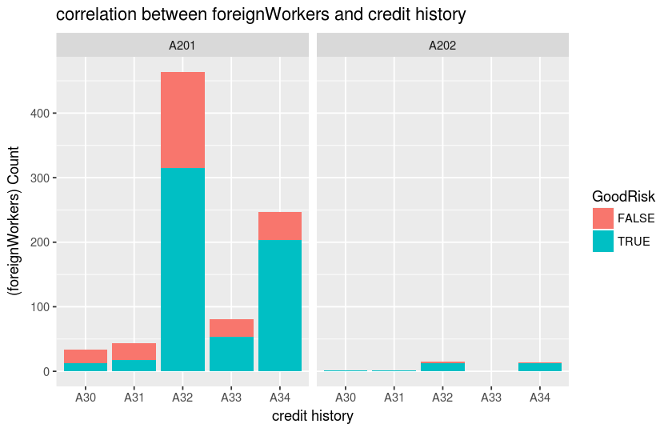

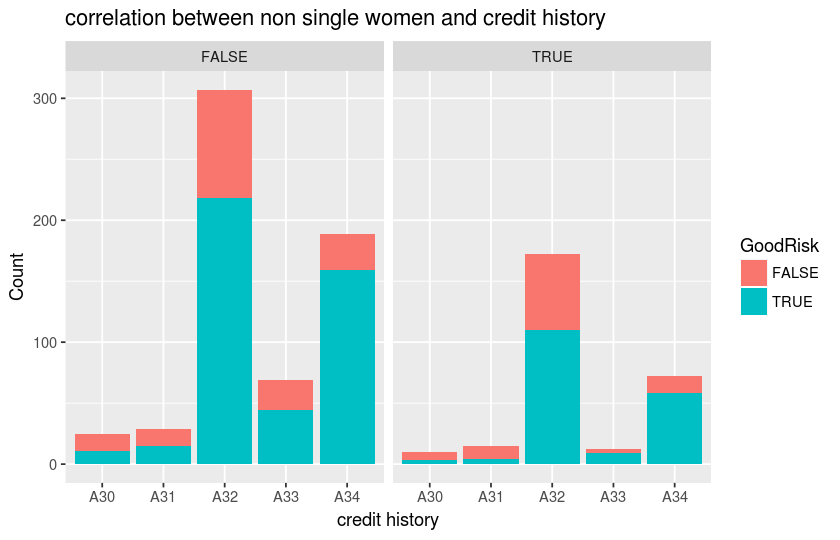

```r
chi_Squared_test(credit_raw$credHistory)

ggplot(train_credit_raw) +
    ggtitle("correlation between foreignWorkers and credit history")+
    aes(x=credHistory, fill=GoodRisk)+
    geom_bar() +
    facet_wrap(~foreignWorkers)+
    xlab("credit history")+
    ylab("(foreignWorkers) Count")


ggplot(train_credit_raw) +
    ggtitle("correlation between non single women and credit history")+
    aes(x=credHistory, fill=GoodRisk)+
    geom_bar() +
    facet_wrap(~personalStatusAndSex=='A92')+
    xlab("credit history")+
    ylab("Count")
```

### Observation

We apply the chisq.test function to the contingency table and found the p-value to be 0.2963 for foreignWorkers and 0.009163 for non single Women.

### Correlation between Protected features and Purpose

```
      other_features
       A40 A41 A410 A42 A43 A44 A45 A46 A48 A49
  A201 213 101   11 175 275  12  21  50   9  96
  A202  21   2    1   6   5   0   1   0   0   1

	Pearson's Chi-squared test

data:  contingency_table_foreignWorkers
X-squared = 27.553, df = 9, p-value = 0.001133

       other_features
        A40 A41 A410 A42 A43 A44 A45 A46 A48 A49
  FALSE 164  79    9 107 195   6  17  29   6  78
  TRUE   70  24    3  74  85   6   5  21   3  19
```

```
	Pearson's Chi-squared test

data:  contingency_table_nonSingleWomen
X-squared = 22.993, df = 9, p-value = 0.006213
```

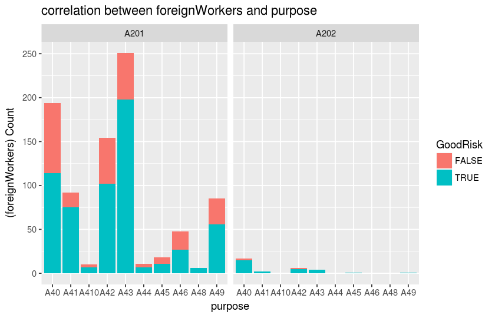

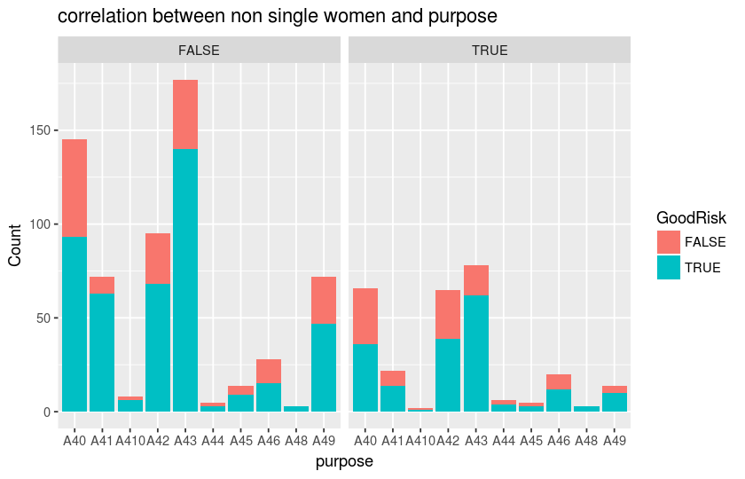

```r
chi_Squared_test(credit_raw$purpose)

ggplot(train_credit_raw) +
    ggtitle("correlation between foreignWorkers and purpose")+
    aes(x=purpose, fill=GoodRisk)+
    geom_bar() +
    facet_wrap(~foreignWorkers)+
    xlab("purpose")+
    ylab("(foreignWorkers) Count")


ggplot(train_credit_raw) +
    ggtitle("correlation between non single women and purpose")+
    aes(x=purpose, fill=GoodRisk)+
    geom_bar() +
    facet_wrap(~personalStatusAndSex=='A92')+
    xlab("purpose")+
    ylab("Count")
```

### Observation

We apply the chisq.test function to the contingency table and found the p-value to be 0.001133 for foreignWorkers and 0.006213 for non single Women.

We observed the p-value for foreignWorkers to be 0.001133 (< 0.05) and 0.006213 (< 0.05) for non single Women. For each of the cases, we have enough statistical evidence to reject the null hypothesis. That's why we state that both foreignWorkers and non single womens are not independent of the purpose with a 0.05 level of significance.

### Correlation between Protected features and Installment Plans

```
      other_features
       A141 A142 A143
  A201  134   47  782
  A202    5    0   32

	Pearson's Chi-squared test

data:  contingency_table_foreignWorkers
X-squared = 1.9321, df = 2, p-value = 0.3806

       other_features
        A141 A142 A143
  FALSE   99   37  554
  TRUE    40   10  260
```

```
	Pearson's Chi-squared test

data:  contingency_table_nonSingleWomen
X-squared = 2.7355, df = 2, p-value = 0.2547
```

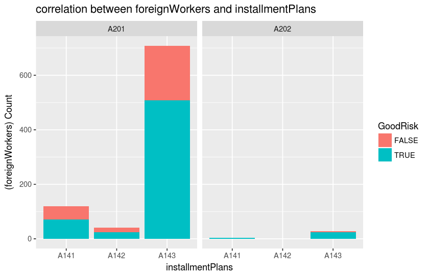

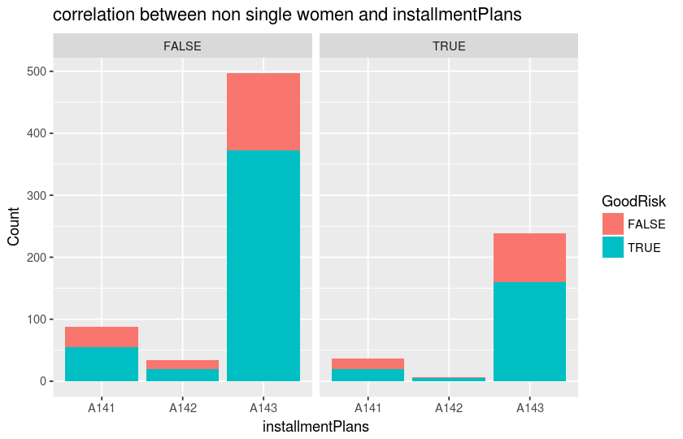

```r
chi_Squared_test(credit_raw$installmentPlans)

ggplot(train_credit_raw) +
    ggtitle("correlation between foreignWorkers and installmentPlans")+
    aes(x=installmentPlans, fill=GoodRisk)+
    geom_bar() +
    facet_wrap(~foreignWorkers)+
    xlab("installmentPlans")+
    ylab("(foreignWorkers) Count")


ggplot(train_credit_raw) +
    ggtitle("correlation between non single women and installmentPlans")+
    aes(x=installmentPlans, fill=GoodRisk)+
    geom_bar() +
    facet_wrap(~personalStatusAndSex=='A92')+
    xlab("installmentPlans")+
    ylab("Count")
```

### Observation

We apply the chisq.test function to the contingency table and found the p-value to be 0.3806 for foreignWorkers and 0.2547 for non single Women.

We observed the p-value for foreignWorkers to be 0.3806 (> 0.05) and 00.2547 (> 0.05) for non single Women. For each of the cases, we do not have enough statistical evidence to reject the null hypothesis. That's why we state that both foreignWorkers and non single womens are independent of the installment plans with a 0.05 level of significance.

### Correlation between Protected features and Debators

```
      other_features
       A101 A102 A103
  A201  880   37   46
  A202   27    4    6

	Pearson's Chi-squared test

data:  contingency_table_foreignWorkers
X-squared = 14.518, df = 2, p-value = 0.0007037

       other_features
        A101 A102 A103
  FALSE  624   29   37
  TRUE   283   12   15
```

```
	Pearson's Chi-squared test

data:  contingency_table_nonSingleWomen
X-squared = 0.18752, df = 2, p-value = 0.9105
```

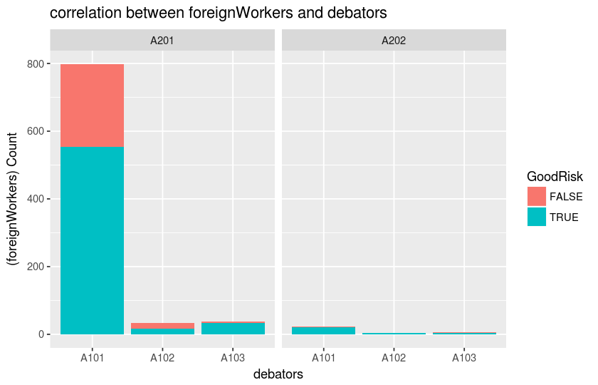

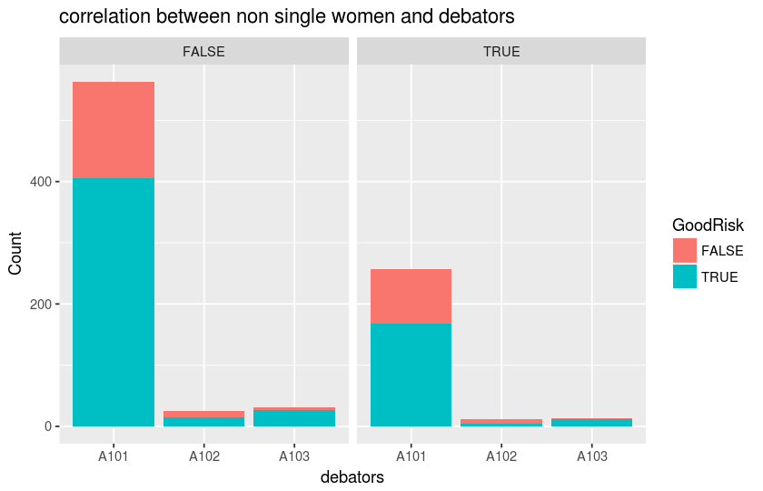

```r
chi_Squared_test(credit_raw$debators)

ggplot(train_credit_raw) +
    ggtitle("correlation between foreignWorkers and debators")+
    aes(x=debators, fill=GoodRisk)+
    geom_bar() +
    facet_wrap(~foreignWorkers)+
    xlab("debators")+
    ylab("(foreignWorkers) Count")


ggplot(train_credit_raw) +
    ggtitle("correlation between non single women and debators")+
    aes(x=debators, fill=GoodRisk)+
    geom_bar() +
    facet_wrap(~personalStatusAndSex=='A92')+
    xlab("debators")+
    ylab("Count")
```

### Observation

We apply the chisq.test function to the contingency table and found the p-value to be 0.0007037 for foreignWorkers and 0.9105 for non single Women.

We observed the p-value for foreignWorkers to be 0.0007037 (< 0.05) and 0.9105 (> 0.05) for non single Women. For foreignWorkers,we have enough statistical evidence to reject the null hypothesis but for non single womens, we do not have enough statistical evidence to reject the null hypothesis. That's why we state that the foreignWorkers is not independent but non single womens is independent of the debators with a 0.05 level of significance

### Correlation between Protected features and Saving Account

```
      other_features
       A61 A62 A63 A64 A65
  A201 581  99  62  45 176
  A202  22   4   1   3   7

	Pearson's Chi-squared test

data:  contingency_table_foreignWorkers
X-squared = 1.6875, df = 4, p-value = 0.793

       other_features
        A61 A62 A63 A64 A65
  FALSE 409  71  47  29 134
  TRUE  194  32  16  19  49
```

```
	Pearson's Chi-squared test

data:  contingency_table_nonSingleWomen
X-squared = 4.4922, df = 4, p-value = 0.3435
```

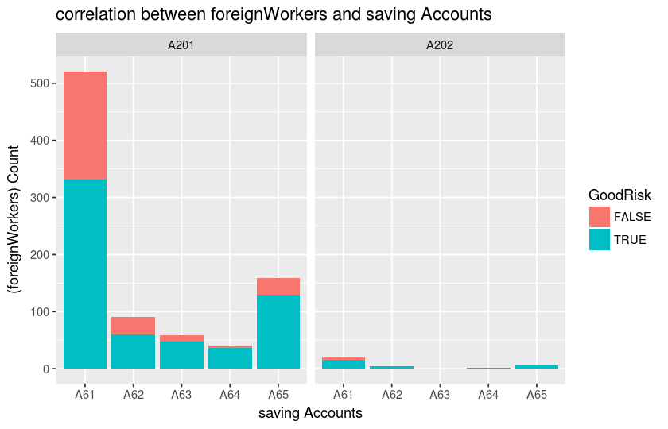

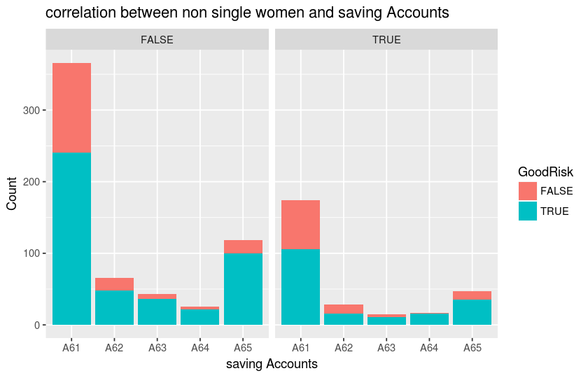

```r
chi_Squared_test(credit_raw$savingAcct)

ggplot(train_credit_raw) +
    ggtitle("correlation between foreignWorkers and saving Accounts")+
    aes(x=savingAcct, fill=GoodRisk)+
    geom_bar() +
    facet_wrap(~foreignWorkers)+
    xlab("saving Accounts")+
    ylab("(foreignWorkers) Count")


ggplot(train_credit_raw) +
    ggtitle("correlation between non single women and saving Accounts")+
    aes(x=savingAcct, fill=GoodRisk)+
    geom_bar() +
    facet_wrap(~personalStatusAndSex=='A92')+
    xlab("saving Accounts")+
    ylab("Count")
```

### Observation

We apply the chisq.test function to the contingency table and found the p-value to be 0.793 for foreignWorkers and 0.3435 for non single Women.

We observed the p-value for foreignWorkers to be 0.793 (> 0.05) and 0.3435 (> 0.05) for non single Women. For each of the cases, we do not have enough statistical evidence to reject the null hypothesis. That's why we state that both foreignWorkers and non single womens are independent of the saving accounts with a 0.05 level of significance.

###### Does it look like your model is indirectly discriminatory against members of our protected classes? Why or why not?

From the observation of the correlation between the protected features and other features that is used in our selected model, we found that the features i.e property and purpose have p-value less than 0.05 level of significance for both protected features(foreignWorkers and non single womens). For each cases, we have enough statistical evidence to reject the null hypothesis. That means both protected features are not independent of property and purpose. The protected features have indirect effect in our model. Thus, we can state that our model is indirectly discriminatory against the members of protected features.

changing the cost weights i.e cost of false positive=3 from the evaluation section

```r
thresholds = seq(min(test_model_4$pred), max(test_model_4$pred), 0.1)
thresholds
```

1. -2.27868353805449

2. -2.17868353805449

3. -2.07868353805449

4. -1.97868353805449

5. -1.87868353805449

6. -1.77868353805449

7. -1.67868353805449

8. -1.57868353805449

9. -1.47868353805449

10. -1.37868353805449

11. -1.27868353805449

12. -1.17868353805449

13. -1.07868353805449

14. -0.978683538054491

15. -0.878683538054491

16. -0.778683538054491

17. -0.678683538054491

18. -0.578683538054491

19. -0.478683538054491

20. -0.378683538054491

21. -0.278683538054491

22. -0.178683538054491

23. -0.0786835380544906

24. 0.0213164619455095

25. 0.12131646194551

26. 0.221316461945509

27. 0.321316461945509

28. 0.421316461945509

29. 0.52131646194551

30. 0.62131646194551

31. 0.721316461945509

32. 0.821316461945509

33. 0.921316461945509

34. 1.02131646194551

35. 1.12131646194551

36. 1.22131646194551

37. 1.32131646194551

38. 1.42131646194551

39. 1.52131646194551

40. 1.62131646194551

41. 1.72131646194551

42. 1.82131646194551

43. 1.92131646194551

44. 2.02131646194551

45. 2.12131646194551

46. 2.22131646194551

47. 2.32131646194551

48. 2.42131646194551

49. 2.52131646194551

50. 2.62131646194551

51. 2.72131646194551

52. 2.82131646194551

53. 2.92131646194551

54. 3.02131646194551

55. 3.12131646194551

56. 3.22131646194551

57. 3.32131646194551

58. 3.42131646194551

59. 3.52131646194551

60. 3.62131646194551

61. 3.72131646194551

62. 3.82131646194551

63. 3.92131646194551

64. 4.02131646194551

65. 4.12131646194551

66. 4.22131646194551

67. 4.32131646194551

68. 4.42131646194551

69. 4.52131646194551

70. 4.62131646194551

71. 4.72131646194551

72. 4.82131646194551

73. 4.92131646194551

74. 5.02131646194551

75. 5.12131646194551

76. 5.22131646194551

77. 5.32131646194551

78. 5.42131646194551

79. 5.52131646194551

80. 5.62131646194551

81. 5.72131646194551

82. 5.82131646194551

83. 5.92131646194551

84. 6.02131646194551

85. 6.12131646194551

86. 6.22131646194551

87. 6.32131646194551

88. 6.42131646194551

89. 6.52131646194551

90. 6.62131646194551

91. 6.72131646194551

92. 6.82131646194551

93. 6.92131646194551

94. 7.02131646194551

95. 7.12131646194551

96. 7.22131646194551

97. 7.32131646194551

98. 7.42131646194551

99. 7.52131646194551

100. 7.62131646194551

101. 7.72131646194551

102. 7.82131646194551

103. 7.92131646194551

104. 8.02131646194551

105. 8.12131646194551

106. 8.22131646194551

107. 8.32131646194551

108. 8.42131646194551

109. 8.52131646194551

110. 8.62131646194551

111. 8.72131646194551

112. 8.82131646194551

113. 8.92131646194551

114. 9.02131646194551

115. 9.12131646194551

116. 9.22131646194551

117. 9.32131646194551

118. 9.42131646194551

119. 9.52131646194551

120. 9.62131646194551

121. 9.72131646194551

122. 9.82131646194551

123. 9.92131646194551

124. 10.0213164619455

125. 10.1213164619455

126. 10.2213164619455

127. 10.3213164619455

128. 10.4213164619455

129. 10.5213164619455

130. 10.6213164619455

131. 10.7213164619455

132. 10.8213164619455

133. 10.9213164619455

134. 11.0213164619455

135. 11.1213164619455

136. 11.2213164619455

137. 11.3213164619455

138. 11.4213164619455

139. 11.5213164619455

140. 11.6213164619455

141. 11.7213164619455

142. 11.8213164619455

143. 11.9213164619455

144. 12.0213164619455

145. 12.1213164619455

146. 12.2213164619455

147. 12.3213164619455

148. 12.4213164619455

149. 12.5213164619455

150. 12.6213164619455

151. 12.7213164619455

152. 12.8213164619455

153. 12.9213164619455

154. 13.0213164619455

155. 13.1213164619455

156. 13.2213164619455

157. 13.3213164619455

158. 13.4213164619455

159. 13.5213164619455

160. 13.6213164619455

161. 13.7213164619455

162. 13.8213164619455

163. 13.9213164619455

164. 14.0213164619455

165. 14.1213164619455

166. 14.2213164619455

167. 14.3213164619455

168. 14.4213164619455

169. 14.5213164619455

170. 14.6213164619455

171. 14.7213164619455

172. 14.8213164619455

173. 14.9213164619455

174. 15.0213164619455

175. 15.1213164619455

176. 15.2213164619455

177. 15.3213164619455

178. 15.4213164619455

179. 15.5213164619455

180. 15.6213164619455

181. 15.7213164619455

182. 15.8213164619455

183. 15.9213164619455

184. 16.0213164619455

```r
costs = function(threshold) {
   test_model_4$sample_outcome = ifelse(test_model_4$pred > threshold, TRUE, FALSE)
   totalcosts= sum((test_model_4$GoodRisk == "TRUE" & test_model_4$sample_outcome == "FALSE") * 1,
                                    (test_model_4$GoodRisk==FALSE & test_model_4$sample_outcome==TRUE)*3)
    return(totalcosts)
}
```

```r
totalcost=apply(data.frame(thresholds), 1, function(x){ costs(x)})
threshold_cost=data.frame(thresholds, totalcost)
head(threshold_cost)
```

| thresholds | totalcost |
| --- | --- |
| -2.278684 | 90 |
| -2.178684 | 90 |
| -2.078684 | 90 |
| -1.978684 | 91 |
| -1.878684 | 91 |
| -1.778684 | 85 |

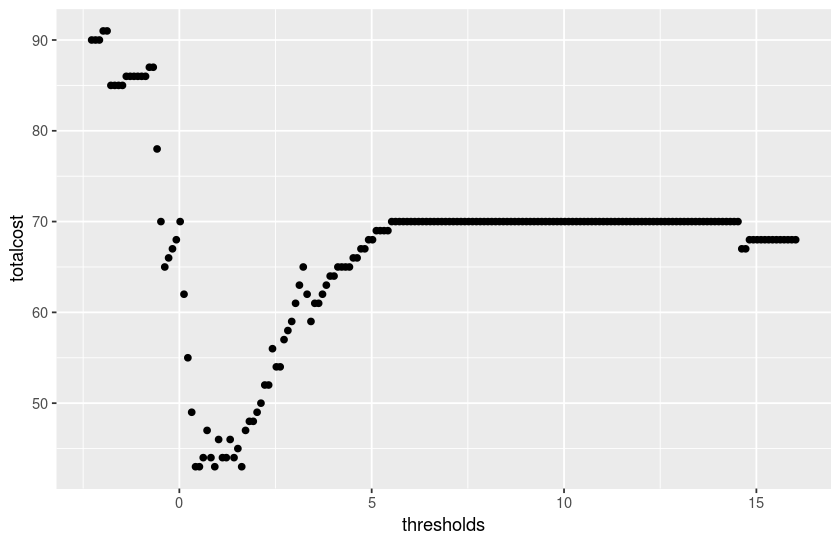

```r
ggplot(threshold_cost) +
    aes(x=thresholds, y=totalcost) +
    geom_point()
```

```r
threshold_mincost=filter(threshold_cost, totalcost==min(totalcost))
threshold_mincost
```

| thresholds | totalcost |
| --- | --- |
| 0.4213165 | 43 |
| 0.5213165 | 43 |
| 0.9213165 | 43 |
| 1.6213165 | 43 |

```r
selected_threshold=threshold_mincost$thresholds[1]
selected_threshold
```

0.421316461945509

```r
recall_precision=function(thresholds){
    dataf = dplyr::select(test_model_4, GoodRisk, pred)
    dataf$sample_outcome = ifelse(dataf$pred > thresholds, TRUE, FALSE)

    TP=sum(dataf$GoodRisk==TRUE & dataf$sample_outcome==TRUE)
    TN=sum(dataf$GoodRisk==FALSE & dataf$sample_outcome==FALSE)
    FP=sum(dataf$GoodRisk==FALSE & dataf$sample_outcome==TRUE)
    FN=sum(dataf$GoodRisk==TRUE & dataf$sample_outcome==FALSE)
    Recall=TP / sum(TP,FN)
    Precision=TP / sum(TP,FP)
    PR=data.frame(Recall, Precision)
    return(PR)

}
recall_precision(selected_threshold)
```

| Recall | Precision |
| --- | --- |
| 0.8115942 | 0.8484848 |

#### observation

As we decrease the cost of false positive, we observed the value of recall increases as compared to the value we got from evaluation section. Thus, model gives better accuracy and less discriminatory.

## comparing best model and model with only protected features

```r
train_model_4 = compute_prediction(model_4, train_credit_raw)
#convert the model predicted value to TRUE FALSE based on the threshold value.
test_model_4$sample_outcome = ifelse(test_model_4$pred > selected_threshold, TRUE, FALSE)
train_model_4$sample_outcome = ifelse(train_model_4$pred > selected_threshold, TRUE, FALSE)

#Convert the protected features to 1 and rest to 0
test_model_4$personalStatusAndSex = ifelse(test_model_4$personalStatusAndSex=='A92',1,0)
train_model_4$personalStatusAndSex = ifelse(train_model_4$personalStatusAndSex=='A92',1,0)
test_model_4$foreignWorkers = ifelse(test_model_4$foreignWorkers=='A201',1,0)
train_model_4$foreignWorkers = ifelse(train_model_4$foreignWorkers=='A201',1,0)

test_model_4$sample_outcome
```

1. TRUE

2. FALSE

3. TRUE

4. TRUE

5. TRUE

6. TRUE

7. FALSE

8. FALSE

9. TRUE

10. TRUE

11. TRUE

12. TRUE

13. TRUE

14. TRUE

15. FALSE

16. TRUE

17. TRUE

18. FALSE

19. TRUE

20. TRUE

21. TRUE

22. TRUE

23. FALSE

24. TRUE

25. FALSE

26. TRUE

27. TRUE

28. TRUE

29. FALSE

30. FALSE

31. TRUE

32. TRUE

33. TRUE

34. FALSE

35. TRUE

36. FALSE

37. TRUE

38. FALSE

39. TRUE

40. TRUE

41. TRUE

42. TRUE

43. FALSE

44. TRUE

45. FALSE

46. TRUE

47. TRUE

48. TRUE

49. TRUE

50. TRUE

51. FALSE

52. TRUE

53. TRUE

54. FALSE

55. TRUE

56. TRUE

57. TRUE

58. TRUE

59. TRUE

60. TRUE

61. FALSE

62. TRUE

63. FALSE

64. TRUE

65. TRUE

66. FALSE

67. TRUE

68. TRUE

69. FALSE

70. FALSE

71. FALSE

72. TRUE

73. TRUE

74. TRUE

75. FALSE

76. TRUE

77. TRUE

78. TRUE

79. TRUE

80. TRUE

81. TRUE

82. FALSE

83. FALSE

84. TRUE

85. TRUE

86. TRUE

87. FALSE

88. FALSE

89. TRUE

90. FALSE

91. FALSE

92. FALSE

93. FALSE

94. TRUE

95. TRUE

96. FALSE

97. TRUE

98. FALSE

99. FALSE

100. TRUE

```r
#Create the train model with only protected features
train_modelWithOnlyProtectedFeatures = model_fitting(sample_outcome ~ personalStatusAndSex + foreignWorkers, train_model_4)
```

```r
#generate test model with only protected features
test__modelWithOnlyProtectedFeatures = compute_prediction(train_modelWithOnlyProtectedFeatures,test_model_4)
```

```r
thresholds = seq(min(test__modelWithOnlyProtectedFeatures$pred), max(test__modelWithOnlyProtectedFeatures$pred), 0.1)
```

```r
costs = function(threshold) {
   test_model_4$sample_outcome = ifelse(test__modelWithOnlyProtectedFeatures$pred > threshold, TRUE, FALSE)
   totalcosts= sum((test__modelWithOnlyProtectedFeatures$GoodRisk == "TRUE" & test__modelWithOnlyProtectedFeatures$sample_outcome == "FALSE") * 1,
                  (test__modelWithOnlyProtectedFeatures$GoodRisk==FALSE & test__modelWithOnlyProtectedFeatures$sample_outcome==TRUE)*5)

    return(totalcosts)
}
```

```r
totalcost=apply(data.frame(thresholds), 1, function(x){ costs(x)})
threshold_cost=data.frame(thresholds, totalcost)
```

```r
threshold_mincost=filter(threshold_cost, totalcost==min(totalcost))
```

```r
selected_threshold=threshold_mincost$thresholds[1]
selected_threshold
```

0.57415509671111

```r
test__modelWithOnlyProtectedFeatures$sample_outcome = ifelse(test__modelWithOnlyProtectedFeatures$pred > selected_threshold, TRUE, FALSE)
test__modelWithOnlyProtectedFeatures$sample_outcome
```

1. TRUE

2. FALSE

3. TRUE

4. TRUE

5. TRUE

6. TRUE

7. TRUE

8. FALSE

9. TRUE

10. FALSE

11. FALSE

12. TRUE

13. TRUE

14. FALSE

15. TRUE

16. TRUE

17. TRUE

18. FALSE

19. TRUE

20. TRUE

21. TRUE

22. FALSE

23. TRUE

24. TRUE

25. TRUE

26. FALSE

27. TRUE

28. FALSE

29. TRUE

30. TRUE

31. TRUE

32. TRUE

33. TRUE

34. TRUE

35. TRUE

36. TRUE

37. FALSE

38. TRUE

39. FALSE

40. TRUE

41. FALSE

42. FALSE

43. TRUE

44. TRUE

45. FALSE

46. TRUE

47. TRUE

48. TRUE

49. TRUE

50. TRUE

51. FALSE

52. FALSE

53. TRUE

54. TRUE

55. FALSE

56. TRUE

57. FALSE

58. TRUE

59. TRUE

60. TRUE

61. TRUE

62. TRUE

63. TRUE

64. TRUE

65. TRUE

66. FALSE

67. FALSE

68. TRUE

69. FALSE

70. TRUE

71. FALSE

72. TRUE

73. TRUE

74. TRUE

75. TRUE

76. TRUE

77. TRUE

78. TRUE

79. TRUE

80. TRUE

81. TRUE

82. TRUE

83. TRUE

84. TRUE

85. TRUE

86. TRUE

87. TRUE

88. FALSE

89. TRUE

90. TRUE

91. FALSE

92. FALSE

93. TRUE

94. FALSE

95. TRUE

96. TRUE

97. TRUE

98. FALSE

99. FALSE

100. TRUE

```r
#calculate the number of rows for which both models have the same predicitons
x=ifelse(test_model_4$sample_outcome==test__modelWithOnlyProtectedFeatures$sample_outcome,TRUE,FALSE)
temp=data.frame(x)
length(temp[temp[1]==TRUE,])
```

64

```r
#Lets subtract the main model predicted value with the value predicted by the model with protected characteristics
head(test_model_4$pred)
head(test__modelWithOnlyProtectedFeatures$pred,5)
residuals_both_models = data.frame(test_model_4$pred,test__modelWithOnlyProtectedFeatures$pred)
residuals_both_models
```

1. 3.17580247307345

2. -0.329493143381365

3. 1.42070857508971

4. 0.68993083793705

5. 2.39207100264721

6. 0.687468866287849

1. 1.9637227029474

2. 0.57415509671111

3. 1.9637227029474

4. 1.9637227029474

5. 0.833519921634323

| test_model_4.pred | test__modelWithOnlyProtectedFeatures.pred |
| --- | --- |
| 3.17580247 | 1.9637227 |
| -0.32949314 | 0.5741551 |
| 1.42070858 | 1.9637227 |
| 0.68993084 | 1.9637227 |
| 2.39207100 | 0.8335199 |
| 0.68746887 | 0.8335199 |
| 0.07598446 | 0.8335199 |
| -0.80484369 | 0.5741551 |
| ⋮ | ⋮ |
| 0.94079065 | 0.5741551 |
| 1.25420336 | 0.8335199 |
| -0.03710937 | 0.8335199 |
| 5.43495393 | 0.8335199 |
| -1.83205285 | 0.5741551 |
| -0.42038325 | 0.5741551 |
| 1.53298483 | 0.8335199 |

```r
test_model_4_error = test_model_4 %>%
                     add_residuals(train_modelWithOnlyProtectedFeatures)
test_model_4_error$resid
```

1. -0.963722702947396

2. -0.57415509671111

3. -0.963722702947396

4. -0.963722702947396

5. 0.166480078365677

6. 0.166480078365677

7. -0.833519921634323

8. -0.57415509671111

9. 0.166480078365677

10. 0.42584490328889

11. 0.42584490328889

12. 0.166480078365677

13. 0.166480078365677

14. 0.42584490328889

15. -0.833519921634323

16. 0.166480078365677

17. 0.166480078365677

18. -0.57415509671111

19. 0.166480078365677

20. 0.166480078365677

21. 0.166480078365677

22. 0.42584490328889

23. -0.833519921634323

24. 0.166480078365677

25. -0.833519921634323

26. 0.42584490328889

27. 0.166480078365677

28. 0.42584490328889

29. -0.833519921634323

30. -0.833519921634323

31. 0.166480078365677

32. 0.166480078365677

33. 0.166480078365677

34. -0.833519921634323

35. 0.166480078365677

36. -1.9637227029474

37. 0.42584490328889

38. -0.833519921634323

39. 0.42584490328889

40. 0.166480078365677

41. 0.42584490328889

42. 0.42584490328889

43. -0.833519921634323

44. 0.166480078365677

45. -0.57415509671111

46. 0.166480078365677

47. 0.166480078365677

48. 0.166480078365677

49. 0.166480078365677

50. 0.166480078365677

51. -0.57415509671111

52. 0.42584490328889

53. -0.963722702947396

54. -0.833519921634323

55. 0.42584490328889

56. 0.166480078365677

57. 0.42584490328889

58. 0.166480078365677

59. 0.166480078365677

60. 0.166480078365677

61. -0.833519921634323

62. 0.166480078365677

63. -0.833519921634323

64. 0.166480078365677

65. 0.166480078365677

66. -0.57415509671111

67. 0.42584490328889

68. 0.166480078365677

69. -0.57415509671111

70. -0.833519921634323

71. -0.57415509671111

72. 0.166480078365677

73. 0.166480078365677

74. 0.166480078365677

75. -1.70435787802418

76. 0.166480078365677

77. 0.166480078365677

78. 0.166480078365677

79. 0.166480078365677

80. 0.166480078365677

81. 0.166480078365677

82. -0.833519921634323

83. -0.833519921634323

84. 0.166480078365677

85. 0.166480078365677

86. 0.166480078365677

87. -0.833519921634323

88. -0.57415509671111

89. 0.166480078365677

90. -0.833519921634323

91. -0.57415509671111

92. -0.57415509671111

93. -0.833519921634323

94. 0.42584490328889

95. 0.166480078365677

96. -0.833519921634323

97. 0.166480078365677

98. -0.57415509671111

99. -0.57415509671111

100. 0.166480078365677

```r
#now we try to predict the residual of the best model with the model of protected characteristics.
model_Error = glm (resid ~ personalStatusAndSex + foreignWorkers, test_model_4_error, family=gaussian())
summary(model_Error)
errorPrediction = test_model_4_error %>%
add_residuals(model_Error)
head(errorPrediction)
```

```
Call:
glm(formula = resid ~ personalStatusAndSex + foreignWorkers,
    family = gaussian(), data = test_model_4_error)

Deviance Residuals:
    Min       1Q   Median       3Q      Max
-0.7197  -0.5179   0.2803   0.2803   0.4821

Coefficients:
                     Estimate Std. Error t value Pr(>|t|)
(Intercept)           -1.2634     0.1935  -6.531 3.01e-09 ***
personalStatusAndSex   0.0576     0.1042   0.552    0.582
foreignWorkers         1.1496     0.1992   5.771 9.43e-08 ***
---
Signif. codes:  0 ‘***’ 0.001 ‘**’ 0.01 ‘*’ 0.05 ‘.’ 0.1 ‘ ’ 1

(Dispersion parameter for gaussian family taken to be 0.2227368)

    Null deviance: 29.225  on 99  degrees of freedom
Residual deviance: 21.605  on 97  degrees of freedom
AIC: 138.57

Number of Fisher Scoring iterations: 2
```

| CAccountStatus | month | credHistory | purpose | credAmount | savingAcct | employedSince | installmentRate | personalStatusAndSex | debators | ⋯ | job | peopleLiableToMaintenance | telephone | foreignWorkers | outcome | GoodRisk | id | pred | sample_outcome | resid |
| --- | --- | --- | --- | --- | --- | --- | --- | --- | --- | --- | --- | --- | --- | --- | --- | --- | --- | --- | --- | --- |
| A13 | 6 | A32 | A40 | 709 | A64 | A72 | 2 | 0 | A101 | ⋯ | A171 | 1 | A191 | 0 | 1 | TRUE | 141 | 3.1758025 | TRUE | 0.2997058 |
| A11 | 12 | A32 | A42 | 1620 | A61 | A73 | 2 | 1 | A102 | ⋯ | A173 | 1 | A191 | 1 | 1 | TRUE | 442 | -0.3294931 | FALSE | -0.5179097 |
| A14 | 10 | A32 | A40 | 1597 | A63 | A73 | 3 | 0 | A101 | ⋯ | A172 | 2 | A191 | 0 | 1 | TRUE | 414 | 1.4207086 | TRUE | 0.2997058 |
| A11 | 15 | A32 | A43 | 1053 | A61 | A72 | 4 | 0 | A101 | ⋯ | A173 | 1 | A191 | 0 | 1 | TRUE | 408 | 0.6899308 | TRUE | 0.2997058 |
| A12 | 6 | A32 | A43 | 484 | A61 | A74 | 3 | 0 | A103 | ⋯ | A172 | 1 | A191 | 1 | 1 | TRUE | 812 | 2.3920710 | TRUE | 0.2803253 |
| A12 | 12 | A34 | A40 | 3124 | A61 | A72 | 1 | 0 | A101 | ⋯ | A172 | 2 | A191 | 1 | 1 | TRUE | 582 | 0.6874689 | TRUE | 0.2803253 |

Let's check correlation between the residuals of the models

```r
contingency_table = table(test_model_4_error$resid, errorPrediction$resid)
contingency_table
chisq.test(contingency_table)
```

```
                     -0.719674684201421 -0.700294168541278 -0.5179096729538
  -1.9637227029474                    0                  1                0
  -1.70435787802418                   0                  0                0
  -0.963722702947396                  0                  0                0
  -0.833519921634323                 19                  0                0
  -0.57415509671111                   0                  0               13
  0.166480078365677                   0                  0                0
  0.42584490328889                    0                  0                0

                     -0.498529157293658 0.280325315798579 0.299705831458722
  -1.9637227029474                    0                 0                 0
  -1.70435787802418                   1                 0                 0
  -0.963722702947396                  0                 0                 4
  -0.833519921634323                  0                 0                 0
  -0.57415509671111                   0                 0                 0
  0.166480078365677                   0                47                 0
  0.42584490328889                    0                 0                 0

                     0.4820903270462
  -1.9637227029474                 0
  -1.70435787802418                0
  -0.963722702947396               0
  -0.833519921634323               0
  -0.57415509671111                0
  0.166480078365677                0
  0.42584490328889                15
```

```
	Pearson's Chi-squared test

data:  contingency_table
X-squared = 600, df = 36, p-value < 2.2e-16
```

The p-value is smaller than 0.05 level of significance. so it seems like there is indirect discrimination

### Limitations

- Accuracy of ground truth:
  - We are building our model assuming that the ground truth is accurate but we could not find much explanation regarding the dataset like how the dataset was collected. So, it is quite difficult to state whether the ground truth is accurate or inaccurate.
- Analysis of our model based on accurate/inaccurate ground truth:
  - Since our model is supervised learning model, the model is manually taught the differences between good risk and bad risk. The accuracy of the prediction of the model depends on the ground truth of the dataset used to train the model. Thus, inaccuracies in the ground truth will directly correlates the inaccuracies in the resulting good risk or bad risk prediction of the model.
- Analysis of the model against historically-discriminatory process:
  - If the training data (ground truth) had followed the discriminatory process during the dataset collection or preparation, then our trained model is more likely to show bias towards the variables that were historically involved in the discrimination process. This also means that our model directly or indirectly use such variables. Our attempt to evaluate such variables being discriminatory should show direct/indirect association with the GoodRisk variable like we discussed in our evaluation of direct and indirect discriminatory section above.
- Analysis of the model against the attempts to detect unjust, illegal or unwanted discrimination:
  - The article https://www.propublica.org/article/machine-bias-risk-assessments-in-criminal-sentencing states how minority group like "black people' are affected by the unjust discrimination of the model used in court that predicts the likelihood of each committing a future crime. Similarly, the model built on the basis of data collected through historically discriminatory process is likely to have unjust or unwanted discrimination if applied in future real world. Since, the model is trained in small number of data, it may not predict accurately in case of all population in real world. For Example, what if our model takes only 20 percent to make prediction? then our model may state the person unillegible for the credit though he is actually illegible.

### Appendix

1. After loading the library MASS used for stepAIC, the select method gives error since this library overrides the method select.
2. Since the value keeps on changing each time we run the code, some observation may differ. we have kept values according to what we got during coding.